# Workload, Schedule Congestion, and Injury Risk in the NBA

A Time-to-Event Perspective - Cox Modelling, Diagnostics and Validation

Alex Martin - Master of Sports Analytics, La Trobe University

06 October 2026

Every model here is re-fitted from `cox_ready_2021-26.rds` when this document knits, nothing is read back from a saved model object. Chunks are cached, so the first knit is slow (the frailty model and the cross-validation folds dominate).

# 1 Stage 0 - The modelling dataset

Feeds article 2.1, 2.3 and Table 1.

```r
# cache.extra ties this chunk's cache to the data file itself. Without it, rebuilding the
# data in scripts 1-5 leaves this chunk's code unchanged, so knitr would silently reuse
# the old dataset and every model downstream would report the previous results.
cox <- readRDS(file.path(BASE, "cox_ready_2021-26.rds"))

# The overuse tier is sub-divided the way Stage 6 reports it, so the reader meets the
# diagnosed / symptom-only counts here rather than for the first time in the results.
.named <- !cox$INJURY_TISSUE %in% c("non_specific", "not_recorded")
.n_diag  <- sum(cox$event_repetitive == 1 &  .named)
.n_sympt <- sum(cox$event_repetitive == 1 & !.named)
.n_unclass <- sum(cox$event) - sum(cox$event_repetitive) -
              sum(cox$event_acute_nc) - sum(cox$event_acute_imp)
f <- function(x) format(x, big.mark = ",")

data_summary <- tibble(
  Quantity = c("Player-game intervals (rows)", "Distinct players", "Seasons",
               "New-injury events (primary outcome)",
               "  - overuse (repetitive mechanism)",
               "      of which: pathology named", "      of which: symptom only",
               "  - acute non-contact", "  - acute impact (negative control)",
               "  - mechanism not classifiable",
               "All-injury events (new + reaggravation)",
               "  - overuse (repetitive mechanism)", "  - acute non-contact",
               "  - acute impact (negative control)"),
  Value = c(
    f(nrow(cox)), f(n_distinct(cox$PLAYER_ID)),
    sprintf("%d (%s to %s)", n_distinct(cox$SEASON), min(cox$SEASON), max(cox$SEASON)),
    f(sum(cox$event)),
    f(sum(cox$event_repetitive)), f(.n_diag), f(.n_sympt),
    f(sum(cox$event_acute_nc)), f(sum(cox$event_acute_imp)), f(.n_unclass),
    f(sum(cox$event_recurrent)),
    f(sum(cox$event_repetitive_recurrent)),
    f(sum(cox$event_acute_nc_recurrent)),
    f(sum(cox$event_acute_imp_recurrent))
  )
)
show_tbl(data_summary, "The counting-process dataset")
```

The counting-process dataset

Quantity

Value

Player-game intervals (rows)

176,202

Distinct players

1,029

Seasons

5 (2021-22 to 2025-26)

New-injury events (primary outcome)

3,981

- overuse (repetitive mechanism)

1,780

of which: pathology named

429

of which: symptom only

1,351

- acute non-contact

1,442

- acute impact (negative control)

604

- mechanism not classifiable

155

All-injury events (new + reaggravation)

5,161

- overuse (repetitive mechanism)

2,371

- acute non-contact

1,777

- acute impact (negative control)

697

Each row is one player-game interval `(t_start, t_stop]` with an event indicator. The clock is game number within a season, and a player only contributes rows while genuinely at risk: once an injury starts the remaining missed games are removed, and they re-enter when they play again.

3,981 new-injury events across 1,029 players. That is large enough that p-values stop being informative on their own, so throughout I read effect size first and significance second.

The mechanism tiers do not quite sum to that total: 155 episodes carry no classifiable mechanism, because every report filed for them was management text with no pathology in it. They stay in the primary outcome, since they are genuine injuries, and drop out only of the tier-specific models in Stage 6.

## 1.1 How I classify injuries

Following the IOC consensus statement (Bahr et al. 2020), which recommends recording body region, tissue type, mechanism and severity independently rather than as one label. The NBA reports support this better than I expected: they are written as `Injury/Illness - <SITE>; <PATHOLOGY>`, so site and pathology are already separate fields, and about nine in ten carry a side.

```r
ep <- cox %>% filter(IS_NEW_INJURY == 1 | IS_REAGGRAVATION == 1)

# A team's schedule density, so I can express the durability window in weeks.
team_games_per_week <- cox %>% distinct(SEASON, TEAM_ID, GAME_DATE) %>%
  group_by(SEASON, TEAM_ID) %>%
  summarise(g = n(), span = as.numeric(max(GAME_DATE) - min(GAME_DATE)), .groups = "drop") %>%
  summarise(gpw = 7 * sum(g) / sum(span)) %>% pull(gpw)

tax_tab <- bind_rows(
  ep %>% count(Level = "Body region (IOC)", Value = INJURY_REGION),
  ep %>% count(Level = "Tissue type (IOC)", Value = INJURY_TISSUE),
  ep %>% count(Level = "Mechanism (IOC)",   Value = INJURY_MECHANISM_IOC),
  ep %>% count(Level = "Side",              Value = INJURY_SIDE)) %>%
  group_by(Level) %>% slice_max(n, n = 6) %>%
  mutate(`%` = round(100 * n / sum(n))) %>% ungroup()
show_tbl(tax_tab, "Injury classification levels (top categories per axis, episode starts)")
```

Injury classification levels (top categories per axis, episode starts)

| Level | Value | n | % |
| --- | --- | --- | --- |
| Body region (IOC) | knee | 1031 | 26 |
| Body region (IOC) | ankle | 1024 | 26 |
| Body region (IOC) | foot | 490 | 13 |
| Body region (IOC) | hip_groin | 465 | 12 |
| Body region (IOC) | lumbosacral | 460 | 12 |
| Body region (IOC) | thigh | 443 | 11 |
| Mechanism (IOC) | repetitive | 2371 | 46 |
| Mechanism (IOC) | acute_noncontact | 1777 | 34 |
| Mechanism (IOC) | acute_impact | 697 | 14 |
| Mechanism (IOC) | unclassified | 316 | 6 |
| Side | right | 2269 | 44 |
| Side | left | 2243 | 43 |
| Side | unspecified | 606 | 12 |
| Side | bilateral | 43 | 1 |
| Tissue type (IOC) | non_specific | 1567 | 31 |
| Tissue type (IOC) | ligament_capsule | 1110 | 22 |
| Tissue type (IOC) | muscle_tendon | 918 | 18 |
| Tissue type (IOC) | not_recorded | 763 | 15 |
| Tissue type (IOC) | superficial | 541 | 11 |
| Tissue type (IOC) | bone | 113 | 2 |

```r
# Severity, in the IOC's time-loss bands.
sev_tab <- readRDS(file.path(BASE, "panel_2021-26.rds")) %>%
  filter(INJURY_TIMELOSS == 1, !is.na(INJURY_EPISODE_ID)) %>%
  count(SEASON, PLAYER_ID, INJURY_EPISODE_ID, name = "games_missed") %>%
  mutate(Severity = factor(injury_severity_ioc(games_missed),
                           levels = c("minimal (1-7 days)", "moderate (8-28 days)",
                                      "severe (>28 days)"))) %>%
  count(Severity) %>% mutate(`%` = round(100 * n / sum(n)))
show_tbl(sev_tab, "Severity of injury episodes, IOC time-loss bands")
```

Severity of injury episodes, IOC time-loss bands

| Severity | n | % |
| --- | --- | --- |
| minimal (1-7 days) | 4113 | 70 |
| moderate (8-28 days) | 1318 | 22 |
| severe (>28 days) | 470 | 8 |

Severity is reported, not modelled. I record it because the IOC asks for it and because it describes the cohort honestly, but my outcome is the onset of an injury, so severity is a property of what follows the event rather than a predictor of it. Modelling severity would be a different study with a different risk set.

Area of opportunity for building into the future building a dynamic aggregation window based on injury severity.

## 1.2 Defining a subsequent injury

The second half of the outcome definition is deciding when a later absence is a new injury and when it is the old one flaring up. IOC, distinguishes an exacerbation (same site, before recovery) from a recurrence (same site, after the athlete has returned to full availability).

“Full availability” is a clinical judgement: being off the injury report does not mean the medical staff consider a player recovered, and I observe nothing about training, rehabilitation or minutes restrictions. So rather than assert a recovery status I do not have, I use the two things I can observe.

First, the classification of each subsequent injury relative to the one before it, using the data-driven level of the SIC-2.0 model (Toohey et al. 2018, extending Finch and Cook 2014). SIC-2.0 exists precisely for datasets without clinical input: its data-driven categories are defined on site, nature and side alone, and the “related / unrelated” judgements sit in a separate clinical tier which I leave unpopulated.

Second, a return-durability rule in place of a recovery judgement. What I am counting is new episodes, and a genuine re-injury is a new episode provided the player got back to playing properly first. So this rule does not merge every repeat. It merges only the ones that arrive before a player has re-established himself, which are the ones most likely to be the original problem never having resolved. A repeat at the same site (region and side) counts as the earlier episode flaring up if the player managed fewer than 8 games in between; anything after that is counted as a new episode in its own right. That is also how the epidemiology consensus treats recurrence: Fuller et al. (2006) classify a same-site injury after return to play as a recurrent injury, not as a continuation.

```r
sic_tab <- cox %>% filter(!is.na(SIC_CATEGORY)) %>%
  count(`SIC-2.0 category` = SIC_CATEGORY, sort = TRUE) %>%
  mutate(`%` = round(100 * n / sum(n), 1))
show_tbl(sic_tab, "Subsequent injuries by SIC-2.0 data-driven category")
```

Subsequent injuries by SIC-2.0 data-driven category

| SIC-2.0 category | n | % |
| --- | --- | --- |
| I index injury | 1567 | 30.4 |
| VIII different site, different nature | 1560 | 30.2 |
| II same site, same nature | 1027 | 19.9 |
| VII different site, same nature | 559 | 10.8 |
| VI same site, different nature | 448 | 8.7 |

Roughly one episode in five is a repeat at the same site with the same tissue type, the category closest to a classical recurrence, and that is before any clinical judgement about relatedness. It is the clearest single number I have for why the recurrent-events models in Stage 4 are worth fitting at all.

## 1.3 What the risk set actually looks like

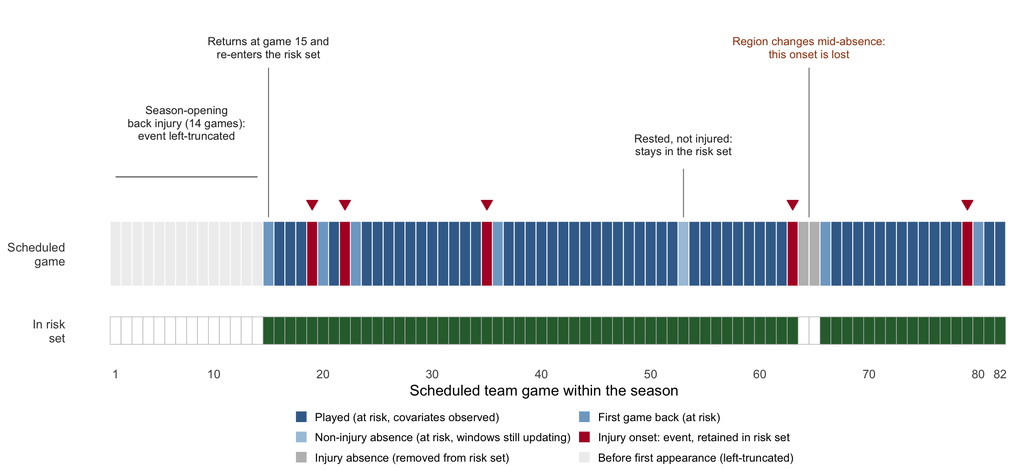

```r
lb <- readRDS(file.path(BASE, "panel_2021-26.rds")) %>%
  filter(PLAYER_NAME == "LeBron James", SEASON == "2025-26") %>%
  arrange(GAME_DATE) %>%
  mutate(
    g      = row_number(),
    tl     = coalesce(INJURY_TIMELOSS, 0L),
    tl_lag = dplyr::lag(tl, default = 0L),
    onset  = as.integer(coalesce(IS_NEW_INJURY, 0L) == 1 | coalesce(IS_REAGGRAVATION, 0L) == 1),
    pre1st = as.integer(cumsum(coalesce(PLAYED_FLAG, 0L)) == 0),   # left truncation
    # The file-5 rule: out only if already absent when the interval opened AND still absent.
    in_risk = as.integer(!(tl == 1 & tl_lag == 1) & pre1st == 0),
    state = case_when(
      pre1st == 1               ~ "Before first appearance (left-truncated)",
      onset == 1 & in_risk == 1 ~ "Injury onset: event, retained in risk set",
      tl == 1 & in_risk == 0    ~ "Injury absence (removed from risk set)",
      PLAYED_FLAG == 0          ~ "Non-injury absence (at risk, windows still updating)",
      tl_lag == 1               ~ "First game back (at risk)",
      TRUE                      ~ "Played (at risk, covariates observed)"))

lev <- c("Played (at risk, covariates observed)",
         "First game back (at risk)",
         "Non-injury absence (at risk, windows still updating)",
         "Injury onset: event, retained in risk set",
         "Injury absence (removed from risk set)",
         "Before first appearance (left-truncated)")
pal <- setNames(c("#3d6d99","#7fa8cc","#a8c5dd","#b2182b","#bdbdbd","#efefef"), lev)
lb$state <- factor(lb$state, levels = lev)

TILE <- 0; RISK <- -0.95
ann  <- function(x, y, lab, col = "grey15")
  annotate("text", x = x, y = y, label = lab, size = 2.8, colour = col, lineheight = 0.95)
lead <- function(x, y0, y1)
  annotate("segment", x = x, xend = x, y = y0, yend = y1, linewidth = 0.3, colour = "grey45")

fig_riskset <- ggplot() +
  geom_tile(data = lb, aes(g, TILE, fill = state), colour = "white", linewidth = .3, height = .8) +
  geom_tile(data = lb, aes(g, RISK), height = .34, colour = "grey75", linewidth = .2,
            fill = ifelse(lb$in_risk == 1, "#2f6b3a", "white")) +
  geom_point(data = filter(lb, state == "Injury onset: event, retained in risk set"),
             aes(g, 0.62), shape = 25, size = 2.4, fill = "#b2182b", colour = "#b2182b") +
  annotate("segment", x = 1, xend = 14, y = 0.95, yend = 0.95, linewidth = .4, colour = "grey45") +
  ann(7.5, 1.62, "Season-opening\nback injury (14 games):\nevent left-truncated") +
  lead(15, 0.45, 2.30) +
  ann(15, 2.55, "Returns at game 15 and\nre-enters the risk set") +
  lead(53, 0.45, 1.05) +
  ann(53, 1.35, "Rested, not injured:\nstays in the risk set") +
  lead(64.5, 0.45, 2.30) +
  ann(64.5, 2.55, "Region changes mid-absence:\nthis onset is lost", "#a0410f") +
  scale_fill_manual(values = pal, name = NULL, drop = FALSE) +
  scale_x_continuous(breaks = c(1, seq(10, 80, 10), 82), expand = expansion(add = c(3.5, 1))) +
  scale_y_continuous(breaks = c(TILE, RISK), labels = c("Scheduled\ngame", "In risk\nset"),
                     limits = c(-1.35, 3.05), expand = c(0, 0)) +
  guides(fill = guide_legend(ncol = 2, byrow = TRUE)) +
  labs(x = "Scheduled team game within the season", y = NULL) +
  theme_minimal(base_size = 10.5) +
  theme(panel.grid = element_blank(),
        axis.text.y = element_text(size = 8.6, colour = "grey25", lineheight = .95),
        legend.position = "bottom", legend.key.size = unit(9, "pt"),
        legend.text = element_text(size = 8), legend.margin = margin(t = -2))

fig_riskset
```

Eighty-two scheduled games become 66 modelled intervals and 5 retained events out of the seven onsets in the season. Three things are worth reading off it.

The rest day at game 53 stays in the risk set. A rested player can still be injured tomorrow, so dropping them would delete exactly the low-load intervals that identify a workload effect.

Two onsets are still lost and both are design costs rather than defects. The season-opening injury precedes any appearance, so it is left-truncated. The game-65 onset fires mid-absence with a different injury, so the filter takes it with the absence around it. File 5 counts that loss on every run.

# 2 Stage 1 - Covariate screening

Feeds article 2.4 and Appendix A.4.

Near-duplicate covariates destabilise a Cox model: effects split between them, standard errors inflate, signs flip. I have several rolling windows of the same quantity, so I screen before fitting rather than rationalising afterwards.

I use Spearman rather than Pearson because these workload distributions are skewed (not linear) and I care about monotone redundancy, not linear redundancy.

```r
candidates <- c(
  "ACWR_MIN", "ROLLING_MIN_7D", "ROLLING_MIN_28D", "ROLLING_MIN_42D",
  "SEASON_CUMULATIVE_MIN", "ROLLING_GAMES_7D", "ROLLING_GAMES_28D",
  "ROLLING_LOAD_7D", "ROLLING_LOAD_28D", "ACWR_LOAD",
  "ROLLING_INTENSITY_7D", "ROLLING_INTENSITY_28D", "INTENSITY",
  "ROLLING_DIST_7D", "ROLLING_DIST_28D", "SEASON_CUMULATIVE_DIST",
  "TEAM_DAYS_REST", "ROLLING_B2B_7D", "ROLLING_B2B_28D",
  "PLAYER_ROAD_TRIP_GAME_NUMBER", "MIN", "DISTANCE",
  "SEASONS_IN_LEAGUE", "CAREER_GAMES_MISSED", "SEASON_GAMES_MISSED",
  "PRIOR_EPISODES_SEASON", "PLAYER_AGE_AT_GAME", "HEIGHT_INCHES", "WEIGHT",
  "PCT_THROUGH_SEASON"
)
candidates <- candidates[candidates %in% names(cox)]

cor_mat <- cor(cox[candidates], use = "pairwise.complete.obs", method = "spearman")
high    <- which(abs(cor_mat) > 0.8 & upper.tri(cor_mat), arr.ind = TRUE)

collinear <- tibble(
  Variable_1 = rownames(cor_mat)[high[, 1]],
  Variable_2 = colnames(cor_mat)[high[, 2]],
  Spearman_r = round(cor_mat[high], 3)
) %>% arrange(desc(abs(Spearman_r)))

show_tbl(collinear, "Collinear pairs (|Spearman r| > 0.8) - only one of each enters the model")
```

Collinear pairs (|Spearman r| > 0.8) - only one of each enters the model

| Variable_1 | Variable_2 | Spearman_r |
| --- | --- | --- |
| ROLLING_MIN_28D | ROLLING_LOAD_28D | 0.997 |
| ROLLING_MIN_7D | ROLLING_LOAD_7D | 0.996 |
| ACWR_MIN | ACWR_LOAD | 0.994 |
| MIN | DISTANCE | 0.984 |
| ROLLING_MIN_28D | ROLLING_MIN_42D | 0.968 |
| ROLLING_MIN_42D | ROLLING_LOAD_28D | 0.964 |
| ROLLING_INTENSITY_7D | ROLLING_INTENSITY_28D | 0.898 |
| ROLLING_GAMES_28D | ROLLING_LOAD_28D | 0.888 |
| ROLLING_MIN_28D | ROLLING_GAMES_28D | 0.883 |
| SEASON_CUMULATIVE_MIN | SEASON_CUMULATIVE_DIST | 0.877 |
| ROLLING_MIN_42D | SEASON_CUMULATIVE_MIN | 0.865 |
| ROLLING_GAMES_7D | ROLLING_LOAD_7D | 0.862 |
| ROLLING_MIN_7D | ROLLING_GAMES_7D | 0.858 |
| SEASONS_IN_LEAGUE | PLAYER_AGE_AT_GAME | 0.856 |
| ROLLING_MIN_42D | ROLLING_GAMES_28D | 0.846 |
| SEASONS_IN_LEAGUE | CAREER_GAMES_MISSED | 0.834 |
| ROLLING_MIN_7D | ROLLING_MIN_28D | 0.819 |
| ROLLING_MIN_7D | ROLLING_LOAD_28D | 0.816 |
| ROLLING_LOAD_7D | ROLLING_LOAD_28D | 0.814 |
| ROLLING_MIN_28D | ROLLING_LOAD_7D | 0.812 |
| ROLLING_MIN_28D | SEASON_CUMULATIVE_MIN | 0.802 |

## 2.1 What it shows

The pairs that breach the 0.8 threshold, cluster into a few obvious families: the overlapping minutes windows, the career-length variables, and the in-game effort measures. For each I keep one on interpretability grounds rather than statistical ones:

- **Neither ACWR term survives to the model.** `ACWR_LOAD` and `ACWR_MIN` are screened here because the acute:chronic ratio is the field’s most cited workload construct and leaving it untested would be a gap. The correlation table already shows the two versions of it are the same variable (r = 0.994), but the reason neither enters is not collinearity with each other - it is that ACWR is a deterministic function of the acute and chronic terms the model carries separately. I set out that argument where the specification is fixed, in Stage 2.

# 3 Stage 2 - Nested models

Feeds article 2.5, 3.1, 3.2, 3.8 and Appendix B.2.

I add covariates in three domain blocks, workload, then schedule congestion, then player context, and ask at each, whether the new domain earns its place. Answering “which domain matters”, rather than producing one flat model where I’d be picking through 24 individually significant coefficients.

Three specification choices carry the design, and each is a deliberate answer to a feature of this data:

[output not shown]

I also z-score every continuous covariate, so each hazard ratio reads as “per 1 standard deviation increase”. That is what makes it legitimate to say chronic load matters more than travel, otherwise I’d be comparing an effect measured in minutes against one measured in kilometres.

```r
z_cols <- c(
  # Workload - minutes, on-court load, intensity
  "ROLLING_MIN_7D", "ROLLING_MIN_28D", "ACWR_MIN", "ROLLING_GAMES_7D", "MIN",
  "PREV_GAME_MIN", "PREV_2GAME_MIN", "PREV_GAME_INTENSITY", "PREV_2GAME_INTENSITY",
  "ROLLING_LOAD_7D", "ROLLING_LOAD_28D", "ACWR_LOAD",
  "PREV_GAME_DISTANCE", "PREV_2GAME_DISTANCE",
  # Travel
  "ROLLING_DIST_7D", "ROLLING_DIST_28D", "SEASON_CUMULATIVE_DIST",
  # Schedule congestion
  "IS_B2B", "ROLLING_B2B_7D", "ROLLING_B2B_28D", "PLAYER_ROAD_TRIP_GAME_NUMBER",
  "TEAM_DAYS_REST",
  # Player context
  "SEASONS_IN_LEAGUE", "CAREER_GAMES_MISSED", "PRIOR_EPISODES_SEASON",
  "PCT_THROUGH_SEASON", "HEIGHT_INCHES", "WEIGHT"
)

cox <- cox %>% mutate(across(all_of(z_cols), ~ as.numeric(scale(.x)), .names = "z_{.col}"))

# Days rest is modelled standardised, so its SD converts the per-SD hazard ratio back
# into the per-extra-rest-day figure the prose compares against Lewis (2018).
sd_rest <- sd(cox$TEAM_DAYS_REST, na.rm = TRUE)

# Two collinearity figures the prose quotes, computed here so they cannot go stale.
r_load_min <- cor(cox$ROLLING_LOAD_28D, cox$ROLLING_MIN_28D, use = "pairwise.complete.obs")
r_int_load <- max(abs(cor(
  cox[c("PREV_GAME_INTENSITY", "PREV_2GAME_INTENSITY")],
  cox[c("ROLLING_LOAD_7D", "ROLLING_LOAD_28D", "PREV_GAME_DISTANCE", "PREV_2GAME_DISTANCE")],
  use = "pairwise.complete.obs")))
```

```r
surv_lhs <- "Surv(t_start, t_stop, event)"
rhs_tail <- "strata(SEASON) + cluster(PLAYER_ID)"

fit_cox <- function(covariate_terms, lhs = surv_lhs) {
  f <- as.formula(paste0(lhs, " ~ ", paste(covariate_terms, collapse = " + "),
                         " + ", rhs_tail))
  coxph(f, data = cox, ties = "efron")
}

m1_terms <- c(
  "z_ROLLING_LOAD_7D",         # acute on-court load (distance)
  "z_ROLLING_LOAD_28D",        # chronic on-court load (distance)
  "z_ROLLING_GAMES_7D",        # acute games played (frequency)
  "z_ROLLING_DIST_7D",         # acute travel load
  "z_ROLLING_DIST_28D",        # chronic travel load
  "z_SEASON_CUMULATIVE_DIST",  # season-long accumulated travel
  "z_PREV_GAME_DISTANCE",      # in-game load, last played game (lag-1, load-management signal)
  "z_PREV_2GAME_DISTANCE"      # in-game load, 2 games back (lag-2, prospective fatigue spike)
)

intensity_terms <- c("z_PREV_GAME_INTENSITY", "z_PREV_2GAME_INTENSITY")

schedule_added <- c(
  "z_IS_B2B","z_ROLLING_B2B_7D", "z_ROLLING_B2B_28D",
  "z_PLAYER_ROAD_TRIP_GAME_NUMBER", "z_TEAM_DAYS_REST", "IS_PLAYER_ROAD_TRIP"
)

context_added <- c(
  "z_SEASONS_IN_LEAGUE", "I(z_SEASONS_IN_LEAGUE^2)",   # tenure, non-linear: Participation
                                                       # Policy rest allowances vs mileage
  "z_CAREER_GAMES_MISSED",                             # career durability
  "z_PRIOR_EPISODES_SEASON", "RECENT_RETURN",          # prior-injury history
  "z_PCT_THROUGH_SEASON", "IS_POST_ALLSTAR",           # season timing
  "PLAYED_PRESEASON", "z_HEIGHT_INCHES", "z_WEIGHT"
)

m2_terms <- c(m1_terms, schedule_added)
m3_terms <- c(m2_terms, context_added)

m3_terms_min <- c("z_ROLLING_MIN_7D", "z_ROLLING_MIN_28D",
                  "z_ROLLING_GAMES_7D", "z_ROLLING_DIST_7D", "z_ROLLING_DIST_28D",
                  "z_SEASON_CUMULATIVE_DIST", "z_PREV_GAME_MIN", "z_PREV_2GAME_MIN",
                  schedule_added, context_added)
```

### 3.0.1 What the acute and chronic load terms actually mean together

This is worth being precise about, because the two windows overlap and that changes how the acute coefficient should be read. The 7-day window sits inside the 28-day window: last week’s load is also part of last month’s load. So the acute coefficient is not “the effect of playing a lot last week”. Holding the 28-day total fixed, it is the effect of the same month’s work being concentrated into the last week rather than spread evenly across the four.

A worked example. Two players arrive at tonight’s game having each covered 40 km over the past month, so their chronic load is identical and the model holds it equal:

- Player A covered 10 km in each of the four weeks. Steady.
- Player B covered 4 km in each of the first three weeks and 28 km last week. Same month, front-loaded.

They are indistinguishable on chronic load. They differ only on acute load, and the acute coefficient is exactly the comparison of B against A: same total work, but crammed into the days immediately before tonight. That is the pattern a fatigue account predicts, so this contrast is where a fatigue effect would show if there is one.

It also explains why the chronic term has to stay in. Fitted on its own, acute load would largely proxy for how much a player plays. Conditioning on chronic load strips the volume out and leaves the concentration, which is the part a fatigue account speaks to.

Recent games played is held fixed as well. So with the windows timed correctly (each ends the day before the game), the acute coefficient compares distance covered in the last week at the same number of recent games and the same chronic load. The number of games itself is carried by the recent-games term. At a fixed number of games, extra distance is mostly extra minutes, so this is still load concentration rather than a direct fatigue measure. The two terms are strongly correlated, and the appendix shows the tier comparison changes when acute load is expressed as distance per recent game instead.

I do not include an acute:chronic workload ratio. ACWR is by construction a function of the two terms already in the model (weekly acute over weekly-average chronic), so adding it puts the same information in three times, and it distorts the chronic coefficient rather than adding anything. The concentration-versus-volume contrast above captures what the ratio was meant to capture, without the redundancy.

In-game load is lagged, not contemporaneous. The current game’s distance is reverse-caused (a player who breaks down logs a low distance in the game it happens) so it reads protective for the wrong reason. I use the last played game and two played games back. Both are known before the interval opens, and they separate two signals: lag-1 carries the load-management pattern, so should read protective through selection; lag-2 sits before that compromise, where a real fatigue spike should show. Cost: first two games each season drop out.

Intensity (distance per minute) is deliberately out of the primary model, and tested separately below. It is close to orthogonal to load (|r| ≤ 0.18) so it is a real construct, not a relabel, but a per-game rate needs a base of minutes to mean anything (I require 10+, which makes it more missing than the load terms) and the rolling windows were null.

The schedule block carries both the accumulated dose and the point-in-time flags, deliberately. The dose is the exposure measure. The flags are contaminated by coaching decisions, since a coach rests an at-risk player tonight. I keep them so the contrast is visible in the results rather than hidden by dropping them, and mark them selection-biased wherever they appear.

## 3.1 Model 1 - Workload

```r
m1 <- fit_cox(m1_terms)
summary(m1)
```

```
#> Call:
#> coxph(formula = Surv(t_start, t_stop, event) ~ z_ROLLING_LOAD_7D +
#>     z_ROLLING_LOAD_28D + z_ROLLING_GAMES_7D + z_ROLLING_DIST_7D +
#>     z_ROLLING_DIST_28D + z_SEASON_CUMULATIVE_DIST + z_PREV_GAME_DISTANCE +
#>     z_PREV_2GAME_DISTANCE + strata(SEASON), data = cox, ties = "efron",
#>     cluster = PLAYER_ID)
#>
#>   n= 167023, number of events= 3928
#>    (9179 observations deleted due to missingness)
#>
#>                               coef exp(coef)  se(coef) robust se       z  Pr(>|z|)
#> z_ROLLING_LOAD_7D        -0.111862  0.894168  0.060333  0.060370  -1.853    0.0639 .
#> z_ROLLING_LOAD_28D        0.620721  1.860269  0.037746  0.044324  14.004   < 2e-16 ***
#> z_ROLLING_GAMES_7D        0.587099  1.798763  0.047071  0.044318  13.247   < 2e-16 ***
#> z_ROLLING_DIST_7D         0.046329  1.047419  0.020977  0.021869   2.118    0.0341 *
#> z_ROLLING_DIST_28D       -0.117542  0.889103  0.029052  0.028485  -4.126 0.0000368 ***
#> z_SEASON_CUMULATIVE_DIST  0.006232  1.006252  0.036410  0.042442   0.147    0.8833
#> z_PREV_GAME_DISTANCE     -0.664057  0.514759  0.031929  0.038850 -17.093   < 2e-16 ***
#> z_PREV_2GAME_DISTANCE     0.509816  1.664985  0.033251  0.035585  14.327   < 2e-16 ***
#> ---
#> Signif. codes:  0 '***' 0.001 '**' 0.01 '*' 0.05 '.' 0.1 ' ' 1
#>
#>                          exp(coef) exp(-coef) lower .95 upper .95
#> z_ROLLING_LOAD_7D           0.8942     1.1184    0.7944    1.0065
#> z_ROLLING_LOAD_28D          1.8603     0.5376    1.7055    2.0291
#> z_ROLLING_GAMES_7D          1.7988     0.5559    1.6491    1.9620
#> z_ROLLING_DIST_7D           1.0474     0.9547    1.0035    1.0933
#> z_ROLLING_DIST_28D          0.8891     1.1247    0.8408    0.9402
#> z_SEASON_CUMULATIVE_DIST    1.0063     0.9938    0.9259    1.0935
#> z_PREV_GAME_DISTANCE        0.5148     1.9427    0.4770    0.5555
#> z_PREV_2GAME_DISTANCE       1.6650     0.6006    1.5528    1.7853
#>
#> Concordance= 0.713  (se = 0.005 )
#> Likelihood ratio test= 2431  on 8 df,   p=<2e-16
#> Wald test            = 1741  on 8 df,   p=<2e-16
#> Score (logrank) test = 2310  on 8 df,   p=<2e-16,   Robust = 411.7  p=<2e-16
#>
#>   (Note: the likelihood ratio and score tests assume independence of
#>      observations within a cluster, the Wald and robust score tests do not).
```

## 3.2 Model 2 - Workload + Schedule

```r
m2 <- fit_cox(m2_terms)
summary(m2)
```

```
#> Call:
#> coxph(formula = Surv(t_start, t_stop, event) ~ z_ROLLING_LOAD_7D +
#>     z_ROLLING_LOAD_28D + z_ROLLING_GAMES_7D + z_ROLLING_DIST_7D +
#>     z_ROLLING_DIST_28D + z_SEASON_CUMULATIVE_DIST + z_PREV_GAME_DISTANCE +
#>     z_PREV_2GAME_DISTANCE + z_IS_B2B + z_ROLLING_B2B_7D + z_ROLLING_B2B_28D +
#>     z_PLAYER_ROAD_TRIP_GAME_NUMBER + z_TEAM_DAYS_REST + IS_PLAYER_ROAD_TRIP +
#>     strata(SEASON), data = cox, ties = "efron", cluster = PLAYER_ID)
#>
#>   n= 167023, number of events= 3928
#>    (9179 observations deleted due to missingness)
#>
#>                                    coef exp(coef) se(coef) robust se       z Pr(>|z|)
#> z_ROLLING_LOAD_7D              -0.14195   0.86767  0.06417   0.06546  -2.168 0.030135 *
#> z_ROLLING_LOAD_28D              0.76021   2.13873  0.04190   0.04894  15.532  < 2e-16 ***
#> z_ROLLING_GAMES_7D              0.78323   2.18854  0.05068   0.04753  16.480  < 2e-16 ***
#> z_ROLLING_DIST_7D               0.03304   1.03359  0.02142   0.02199   1.503 0.132929
#> z_ROLLING_DIST_28D             -0.09772   0.90690  0.02937   0.02862  -3.415 0.000639 ***
#> z_SEASON_CUMULATIVE_DIST        0.01536   1.01548  0.03640   0.04083   0.376 0.706679
#> z_PREV_GAME_DISTANCE           -0.68803   0.50256  0.03251   0.03993 -17.233  < 2e-16 ***
#> z_PREV_2GAME_DISTANCE           0.47479   1.60767  0.03412   0.03619  13.120  < 2e-16 ***
#> z_IS_B2B                       -0.19971   0.81897  0.01908   0.03247  -6.151 7.71e-10 ***
#> z_ROLLING_B2B_7D               -0.11913   0.88769  0.02111   0.02176  -5.475 4.39e-08 ***
#> z_ROLLING_B2B_28D              -0.19178   0.82548  0.02399   0.02641  -7.262 3.82e-13 ***
#> z_PLAYER_ROAD_TRIP_GAME_NUMBER  0.03229   1.03281  0.02738   0.02649   1.219 0.222819
#> z_TEAM_DAYS_REST               -0.14650   0.86372  0.03214   0.05845  -2.507 0.012188 *
#> IS_PLAYER_ROAD_TRIP            -0.21574   0.80595  0.05763   0.05843  -3.692 0.000222 ***
#> ---
#> Signif. codes:  0 '***' 0.001 '**' 0.01 '*' 0.05 '.' 0.1 ' ' 1
#>
#>                                exp(coef) exp(-coef) lower .95 upper .95
#> z_ROLLING_LOAD_7D                 0.8677     1.1525    0.7632    0.9865
#> z_ROLLING_LOAD_28D                2.1387     0.4676    1.9431    2.3541
#> z_ROLLING_GAMES_7D                2.1885     0.4569    1.9939    2.4022
#> z_ROLLING_DIST_7D                 1.0336     0.9675    0.9900    1.0791
#> z_ROLLING_DIST_28D                0.9069     1.1027    0.8574    0.9592
#> z_SEASON_CUMULATIVE_DIST          1.0155     0.9848    0.9374    1.1001
#> z_PREV_GAME_DISTANCE              0.5026     1.9898    0.4647    0.5435
#> z_PREV_2GAME_DISTANCE             1.6077     0.6220    1.4976    1.7258
#> z_IS_B2B                          0.8190     1.2210    0.7685    0.8728
#> z_ROLLING_B2B_7D                  0.8877     1.1265    0.8506    0.9264
#> z_ROLLING_B2B_28D                 0.8255     1.2114    0.7838    0.8693
#> z_PLAYER_ROAD_TRIP_GAME_NUMBER    1.0328     0.9682    0.9806    1.0878
#> z_TEAM_DAYS_REST                  0.8637     1.1578    0.7702    0.9686
#> IS_PLAYER_ROAD_TRIP               0.8059     1.2408    0.7187    0.9037
#>
#> Concordance= 0.721  (se = 0.005 )
#> Likelihood ratio test= 2736  on 14 df,   p=<2e-16
#> Wald test            = 1826  on 14 df,   p=<2e-16
#> Score (logrank) test = 2541  on 14 df,   p=<2e-16,   Robust = 417.1  p=<2e-16
#>
#>   (Note: the likelihood ratio and score tests assume independence of
#>      observations within a cluster, the Wald and robust score tests do not).
```

## 3.3 Model 3 - Workload + Schedule + Player context

```r
m3 <- fit_cox(m3_terms)
summary(m3)
```

```
#> Call:
#> coxph(formula = Surv(t_start, t_stop, event) ~ z_ROLLING_LOAD_7D +
#>     z_ROLLING_LOAD_28D + z_ROLLING_GAMES_7D + z_ROLLING_DIST_7D +
#>     z_ROLLING_DIST_28D + z_SEASON_CUMULATIVE_DIST + z_PREV_GAME_DISTANCE +
#>     z_PREV_2GAME_DISTANCE + z_IS_B2B + z_ROLLING_B2B_7D + z_ROLLING_B2B_28D +
#>     z_PLAYER_ROAD_TRIP_GAME_NUMBER + z_TEAM_DAYS_REST + IS_PLAYER_ROAD_TRIP +
#>     z_SEASONS_IN_LEAGUE + I(z_SEASONS_IN_LEAGUE^2) + z_CAREER_GAMES_MISSED +
#>     z_PRIOR_EPISODES_SEASON + RECENT_RETURN + z_PCT_THROUGH_SEASON +
#>     IS_POST_ALLSTAR + PLAYED_PRESEASON + z_HEIGHT_INCHES + z_WEIGHT +
#>     strata(SEASON), data = cox, ties = "efron", cluster = PLAYER_ID)
#>
#>   n= 166703, number of events= 3921
#>    (9499 observations deleted due to missingness)
#>
#>                                     coef exp(coef)  se(coef) robust se       z      Pr(>|z|)
#> z_ROLLING_LOAD_7D              -0.038198  0.962522  0.065840  0.066378  -0.575      0.564977
#> z_ROLLING_LOAD_28D              0.746440  2.109476  0.042893  0.049389  15.113       < 2e-16 ***
#> z_ROLLING_GAMES_7D              0.716045  2.046324  0.052651  0.047811  14.977       < 2e-16 ***
#> z_ROLLING_DIST_7D               0.035973  1.036628  0.021413  0.022314   1.612      0.106929
#> z_ROLLING_DIST_28D             -0.117596  0.889055  0.029636  0.028916  -4.067 0.00004766187 ***
#> z_SEASON_CUMULATIVE_DIST        0.074152  1.076971  0.037776  0.042382   1.750      0.080188 .
#> z_PREV_GAME_DISTANCE           -0.761748  0.466850  0.033263  0.040714 -18.710       < 2e-16 ***
#> z_PREV_2GAME_DISTANCE           0.415248  1.514746  0.035341  0.037559  11.056       < 2e-16 ***
#> z_IS_B2B                       -0.187410  0.829104  0.018900  0.030838  -6.077 0.00000000122 ***
#> z_ROLLING_B2B_7D               -0.126617  0.881071  0.021217  0.021787  -5.812 0.00000000619 ***
#> z_ROLLING_B2B_28D              -0.120922  0.886103  0.024390  0.025907  -4.668 0.00000304886 ***
#> z_PLAYER_ROAD_TRIP_GAME_NUMBER  0.029757  1.030204  0.027368  0.026006   1.144      0.252534
#> z_TEAM_DAYS_REST               -0.139729  0.869594  0.030956  0.053400  -2.617      0.008880 **
#> IS_PLAYER_ROAD_TRIP            -0.216881  0.805025  0.057661  0.058140  -3.730      0.000191 ***
#> z_SEASONS_IN_LEAGUE             0.104260  1.109889  0.034324  0.049337   2.113      0.034580 *
#> I(z_SEASONS_IN_LEAGUE^2)       -0.049571  0.951638  0.013515  0.021604  -2.295      0.021759 *
#> z_CAREER_GAMES_MISSED           0.146829  1.158156  0.024403  0.036014   4.077 0.00004562563 ***
#> z_PRIOR_EPISODES_SEASON         0.191863  1.211504  0.014889  0.021748   8.822       < 2e-16 ***
#> RECENT_RETURN                  -0.118687  0.888086  0.048924  0.052587  -2.257      0.024012 *
#> z_PCT_THROUGH_SEASON           -0.597080  0.550417  0.105505  0.118587  -5.035 0.00000047796 ***
#> IS_POST_ALLSTAR                 0.757100  2.132083  0.154303  0.151936   4.983 0.00000062599 ***
#> PLAYED_PRESEASON               -0.083218  0.920150  0.066096  0.067954  -1.225      0.220715
#> z_HEIGHT_INCHES                 0.025717  1.026051  0.024422  0.038148   0.674      0.500220
#> z_WEIGHT                       -0.006443  0.993577  0.024755  0.038867  -0.166      0.868328
#> ---
```

[output cut: 20 more lines]

```
#> z_PRIOR_EPISODES_SEASON           1.2115     0.8254    1.1609    1.2643
#> RECENT_RETURN                     0.8881     1.1260    0.8011    0.9845
#> z_PCT_THROUGH_SEASON              0.5504     1.8168    0.4363    0.6944
#> IS_POST_ALLSTAR                   2.1321     0.4690    1.5830    2.8717
#> PLAYED_PRESEASON                  0.9202     1.0868    0.8054    1.0512
#> z_HEIGHT_INCHES                   1.0261     0.9746    0.9521    1.1057
#> z_WEIGHT                          0.9936     1.0065    0.9207    1.0722
#>
#> Concordance= 0.738  (se = 0.005 )
#> Likelihood ratio test= 3145  on 24 df,   p=<2e-16
#> Wald test            = 2168  on 24 df,   p=<2e-16
#> Score (logrank) test = 2922  on 24 df,   p=<2e-16,   Robust = 428.1  p=<2e-16
#>
#>   (Note: the likelihood ratio and score tests assume independence of
#>      observations within a cluster, the Wald and robust score tests do not).
```

## 3.4 Does each domain earn its place?

A likelihood-ratio test is not valid here. `cluster(PLAYER_ID)` does not change the likelihood, only the variance estimated afterwards, so an LRT would read the uncorrected likelihood diregarding the clustering adjustment. I use a robust Wald test on the newly-added block instead, built from the clustered covariance, plus the change in concordance.

```r
# Joint H0 test that the coefficients in a model are all zero, using the robust (clustered) covariance.
robust_wald <- function(model, added_terms) {
  cf   <- coef(model)
  norm <- function(s) gsub("\\s", "", s)      # I(x^2) spacing varies; match robustly
  idx  <- which(norm(names(cf)) %in% norm(added_terms))
  V    <- vcov(model)[idx, idx, drop = FALSE] # robust vcov of just those coefficients
  b    <- cf[idx]
  stat <- as.numeric(t(b) %*% solve(V) %*% b) # Wald statistic: b' V^-1 b
  tibble(block_df = length(idx), wald_chisq = round(stat, 2),
         p_value  = signif(pchisq(stat, length(idx), lower.tail = FALSE), 4))
}

nested <- bind_rows(
  robust_wald(m2, schedule_added) %>% mutate(block = "Schedule (added to Model 1)"),
  robust_wald(m3, context_added)  %>% mutate(block = "Player context (added to Model 2)")
) %>%
  select(block, block_df, wald_chisq, p_value) %>%
  mutate(p_value = fmt_p(p_value))

concordance_progression <- tibble(
  Model = c("Model 1 - workload", "Model 2 - + schedule", "Model 3 - + player context"),
  Concordance = c(summary(m1)$concordance[1],
                  summary(m2)$concordance[1],
                  summary(m3)$concordance[1]) %>% round(4)
)

show_tbl(nested, "Robust Wald tests on each added block")
```

Robust Wald tests on each added block

| block | block_df | wald_chisq | p_value |
| --- | --- | --- | --- |
| Schedule (added to Model 1) | 6 | 175.69 | 2.79e-35 |
| Player context (added to Model 2) | 10 | 249.39 | 7.30e-48 |

```r
show_tbl(concordance_progression, "Discrimination as each domain is added")
```

Discrimination as each domain is added

| Model | Concordance |
| --- | --- |
| Model 1 - workload | 0.713 |
| Model 2 - + schedule | 0.722 |
| Model 3 - + player context | 0.738 |

```r
m3_tidy <- tidy(m3, exponentiate = TRUE, conf.int = TRUE) %>%
  mutate(effect_size = abs(estimate - 1)) %>%
  arrange(desc(effect_size)) %>%
  select(term, HR = estimate, conf.low, conf.high, p.value, robust.se) %>%
  mutate(p.value = fmt_p(p.value))

show_tbl(m3_tidy, "Model 3 - hazard ratios, sorted by effect size (not by p)")
```

Model 3 - hazard ratios, sorted by effect size (not by p)

| term | HR | conf.low | conf.high | p.value | robust.se |
| --- | --- | --- | --- | --- | --- |
| IS_POST_ALLSTAR | 2.132 | 1.583 | 2.872 | 6.26e-07 | 0.152 |
| z_ROLLING_LOAD_28D | 2.109 | 1.915 | 2.324 | 1.32e-51 | 0.049 |
| z_ROLLING_GAMES_7D | 2.046 | 1.863 | 2.247 | 1.04e-50 | 0.048 |
| z_PREV_GAME_DISTANCE | 0.467 | 0.431 | 0.506 | 4.11e-78 | 0.041 |
| z_PREV_2GAME_DISTANCE | 1.515 | 1.407 | 1.630 | 2.05e-28 | 0.038 |
| z_PCT_THROUGH_SEASON | 0.550 | 0.436 | 0.694 | 4.78e-07 | 0.119 |
| z_PRIOR_EPISODES_SEASON | 1.212 | 1.161 | 1.264 | 1.12e-18 | 0.022 |
| IS_PLAYER_ROAD_TRIP | 0.805 | 0.718 | 0.902 | 1.91e-04 | 0.058 |
| z_IS_B2B | 0.829 | 0.780 | 0.881 | 1.22e-09 | 0.031 |
| z_CAREER_GAMES_MISSED | 1.158 | 1.079 | 1.243 | 4.56e-05 | 0.036 |
| z_TEAM_DAYS_REST | 0.870 | 0.783 | 0.966 | 0.009 | 0.053 |
| z_ROLLING_B2B_7D | 0.881 | 0.844 | 0.920 | 6.19e-09 | 0.022 |
| z_ROLLING_B2B_28D | 0.886 | 0.842 | 0.932 | 3.05e-06 | 0.026 |
| RECENT_RETURN | 0.888 | 0.801 | 0.985 | 0.024 | 0.053 |
| z_ROLLING_DIST_28D | 0.889 | 0.840 | 0.941 | 4.77e-05 | 0.029 |
| z_SEASONS_IN_LEAGUE | 1.110 | 1.008 | 1.223 | 0.035 | 0.049 |
| PLAYED_PRESEASON | 0.920 | 0.805 | 1.051 | 0.221 | 0.068 |
| z_SEASON_CUMULATIVE_DIST | 1.077 | 0.991 | 1.170 | 0.080 | 0.042 |
| I(z_SEASONS_IN_LEAGUE^2) | 0.952 | 0.912 | 0.993 | 0.022 | 0.022 |
| z_ROLLING_LOAD_7D | 0.963 | 0.845 | 1.096 | 0.565 | 0.066 |
| z_ROLLING_DIST_7D | 1.037 | 0.992 | 1.083 | 0.107 | 0.022 |
| z_PLAYER_ROAD_TRIP_GAME_NUMBER | 1.030 | 0.979 | 1.084 | 0.253 | 0.026 |
| z_HEIGHT_INCHES | 1.026 | 0.952 | 1.106 | 0.500 | 0.038 |
| z_WEIGHT | 0.994 | 0.921 | 1.072 | 0.868 | 0.039 |

## 3.5 What it shows

Both blocks earn their place and concordance climbs to 0.738: given two comparable intervals, the model ranks the one that gets injured higher about 74% of the time against 50% by chance. From public box-score and schedule data alone, no GPS, no medical screening, no training load, I read that as close to the honest ceiling. Establishing where that ceiling sits is itself worth knowing.

Chronic 28-day load is the headline at HR 2.1 per SD.

Two point-in-time flags read protective, the back-to-back and the road-trip flag. Playing the second night of a back-to-back is not safer. It is health-gating, since a coach sits a player carrying something, so the flag partly records who was judged fit. Both vary between team-mates on the same date, which is the tell. This is why I interpret the accumulated dose measures instead.

Team days rest is the opposite case. Protective at HR 0.87, which is what physiology predicts rather than a puzzle, and it is the one schedule covariate that cannot be health-gated: it comes off the fixture list and every team-mate shares it on a given date. Its SD is 1.05 days, so that is 12.4% lower hazard per extra rest day, against Lewis (2018) reporting 15.96% lower odds on different seasons with a different model. Scheduled rest is less subject to individual rest decisions than the other schedule terms, though not immune to confounding, and the two estimates agree in direction and order of magnitude. Its size is sensitive to how the workload windows are timed, so I would not claim more than that.

`RECENT_RETURN` is the clearest case of the same thing. A player in the fortnight after returning carries HR 0.888, lower hazard, against a literature expecting return-to-play to be high risk. Nobody returns before medical staff clear them and nobody comes back to a full load. It measures who was permitted to play, not whether returning is safe, and carries the same selection asterisk.

# 4 Stage 3 - The proportional-hazards assumption

Feeds article 2.6, 3.3 and Appendix B.1.

Cox assumes each covariate’s effect is constant over time: heavy chronic load as dangerous in game 70 as in game 10. Testable with scaled Schoenfeld residuals, which ask whether the covariate values of the players who fail drift as the season progresses.

A violation here would be a finding, not a problem, since it would mean a risk factor intensifies or fades across a season, which only the time-to-event framing can surface. I went in hoping to find one.

`transform = "identity"` keeps the axis as raw game number, so the plotted trend is readable against any time-interaction I might fit.

```r
zph1 <- cox.zph(m1, transform = "identity")
zph2 <- cox.zph(m2, transform = "identity")
zph3 <- cox.zph(m3, transform = "identity")

zph3_tab <- as.data.frame(zph3$table) %>%
  rownames_to_column("term") %>%
  as_tibble() %>%
  mutate(flag = if_else(term != "GLOBAL" & p < 0.05, "** VIOLATES", "")) %>%
  arrange(term == "GLOBAL", p)

plot_terms <- zph3_tab %>% filter(term != "GLOBAL") %>% pull(term)  # GLOBAL has no curve to plot

zph3_tab %>%
  mutate(chisq = round(chisq, 2), p = fmt_p(p)) %>%
  show_tbl("Model 3 - proportional-hazards test (scaled Schoenfeld residuals)")
```

Model 3 - proportional-hazards test (scaled Schoenfeld residuals)

| term | chisq | df | p | flag |
| --- | --- | --- | --- | --- |
| z_PRIOR_EPISODES_SEASON | 10.08 | 1 | 0.002 | ** VIOLATES |
| z_PREV_2GAME_DISTANCE | 8.73 | 1 | 0.003 | ** VIOLATES |
| z_CAREER_GAMES_MISSED | 7.54 | 1 | 0.006 | ** VIOLATES |
| z_PREV_GAME_DISTANCE | 6.31 | 1 | 0.012 | ** VIOLATES |
| IS_PLAYER_ROAD_TRIP | 5.63 | 1 | 0.018 | ** VIOLATES |
| z_SEASONS_IN_LEAGUE | 5.31 | 1 | 0.021 | ** VIOLATES |
| z_PLAYER_ROAD_TRIP_GAME_NUMBER | 5.15 | 1 | 0.023 | ** VIOLATES |
| z_IS_B2B | 4.79 | 1 | 0.029 | ** VIOLATES |
| PLAYED_PRESEASON | 4.50 | 1 | 0.034 | ** VIOLATES |
| I(z_SEASONS_IN_LEAGUE^2) | 4.44 | 1 | 0.035 | ** VIOLATES |
| z_ROLLING_DIST_7D | 4.37 | 1 | 0.037 | ** VIOLATES |
| z_ROLLING_GAMES_7D | 2.63 | 1 | 0.105 |  |
| IS_POST_ALLSTAR | 1.90 | 1 | 0.168 |  |
| RECENT_RETURN | 1.45 | 1 | 0.228 |  |
| z_PCT_THROUGH_SEASON | 1.44 | 1 | 0.230 |  |
| z_ROLLING_LOAD_7D | 1.26 | 1 | 0.261 |  |
| z_WEIGHT | 0.42 | 1 | 0.516 |  |
| z_ROLLING_LOAD_28D | 0.37 | 1 | 0.544 |  |
| z_ROLLING_B2B_7D | 0.23 | 1 | 0.629 |  |
| z_HEIGHT_INCHES | 0.11 | 1 | 0.740 |  |
| z_SEASON_CUMULATIVE_DIST | 0.02 | 1 | 0.891 |  |
| z_ROLLING_B2B_28D | 0.01 | 1 | 0.918 |  |
| z_TEAM_DAYS_REST | 0.01 | 1 | 0.926 |  |
| z_ROLLING_DIST_28D | 0.00 | 1 | 0.971 |  |
| GLOBAL | 93.15 | 24 | 4.31e-10 |  |

11 individual covariates flagged at p < 0.05 (the two lag in-game load terms among them, at p = 0.012 and 0.003).

## 4.1 The plots, which is where the decision actually got made

A p-value only says the slope is not exactly zero, and at 3,921 events a near-flat line still tests significant. Shape is what matters, so I plot every term: flat means the assumption holds, sloping means the effect drifts.

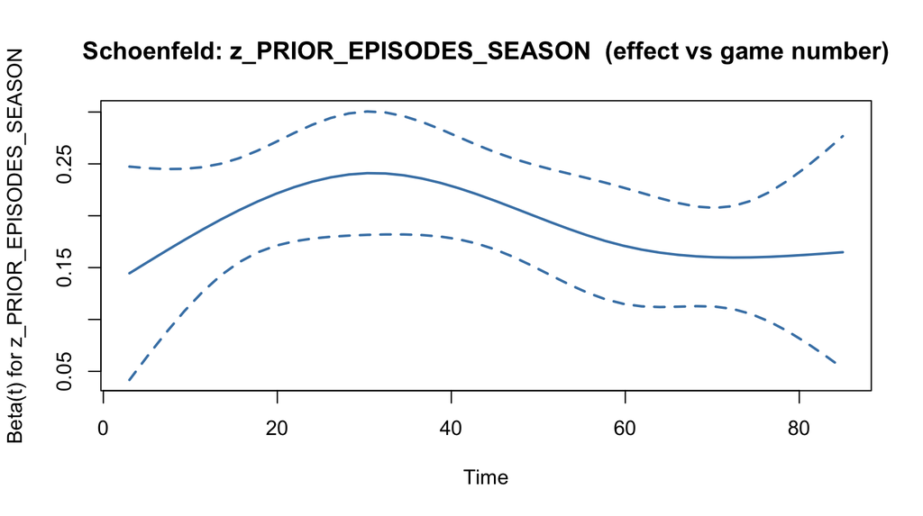

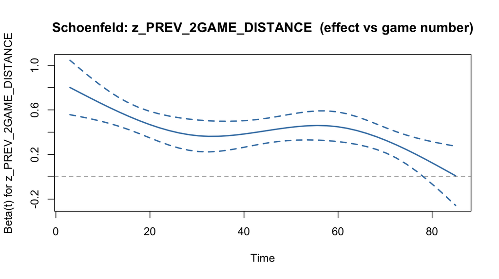

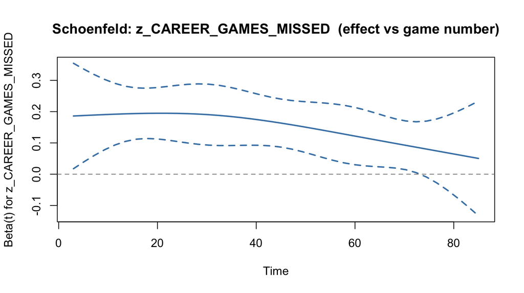

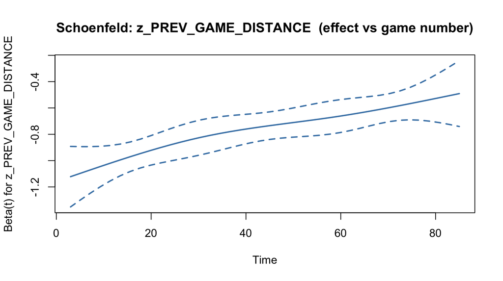

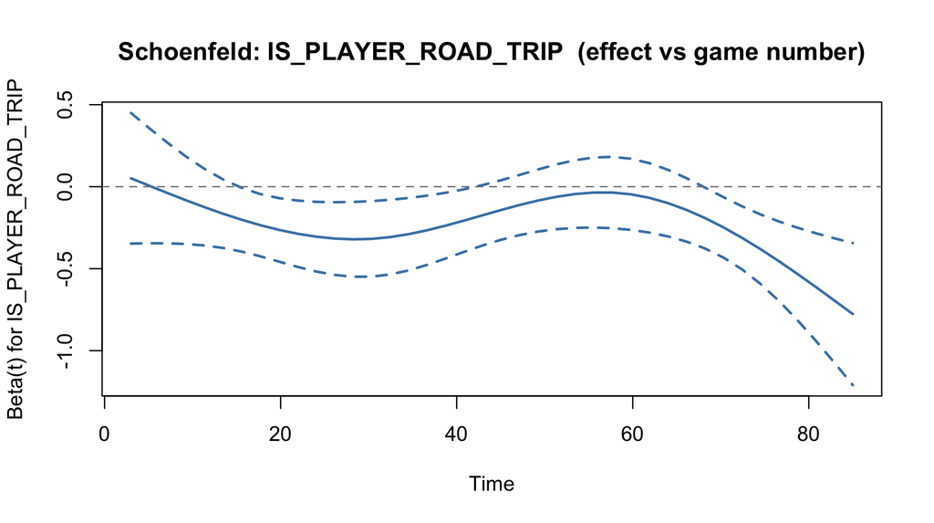

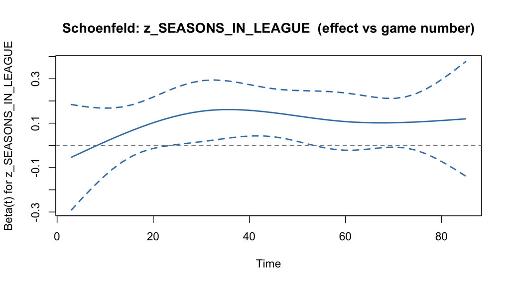

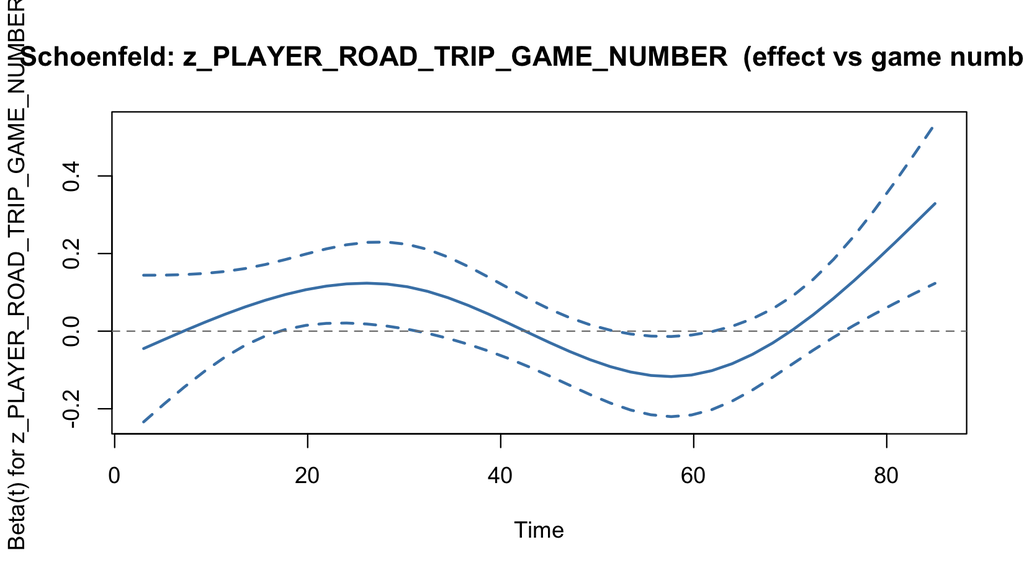

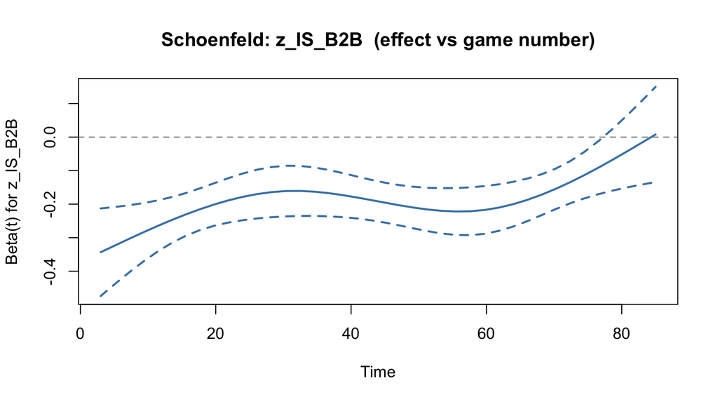

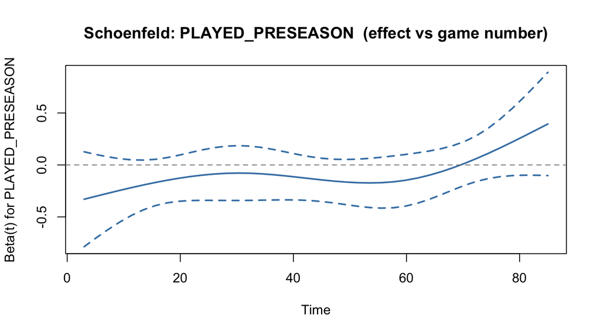

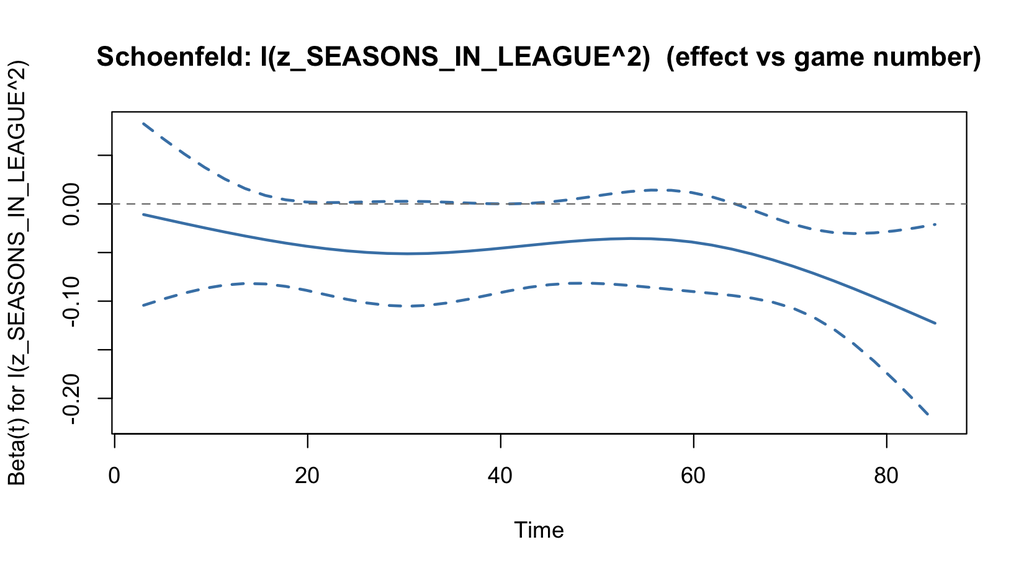

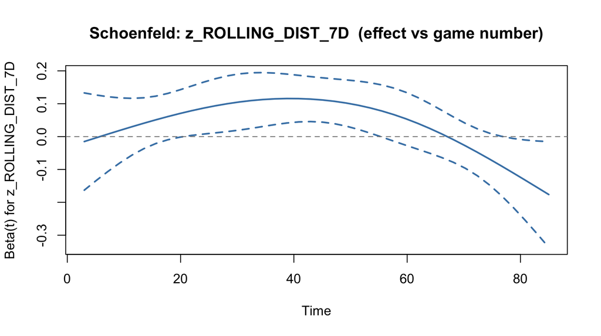

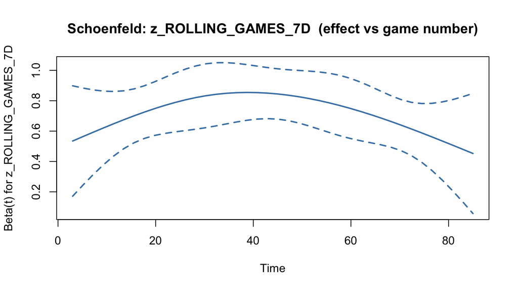

[12 more figures not shown]

```r
for (v in plot_terms) {
  idx <- which(rownames(zph3$table) == v)
  plot(zph3[idx], resid = FALSE, lwd = 2, col = "steelblue",
       main = paste0("Schoenfeld: ", v, "  (effect vs game number)"))
  abline(h = 0, col = "grey50", lty = 2)
}
```

## 4.2 What it shows, and why I remedied nothing

The global test was always going to reject at 3,921 events (p = 4.31e-10), and 11 terms flag individually. Significance is not the question here. What settles it is the shape of each drift and whether any of it is biological. Decomposing by drift direction says it is not.

```r
# Direction of each violation: does beta(t) weaken TOWARD zero (the effect fading)
bhat <- coef(m3)
vt   <- zph3_tab %>% filter(flag != "") %>% pull(term)
slope_sign <- sapply(vt, function(v) sign(cov(zph3$x, zph3$y[, match(v, colnames(zph3$y))])))
reading <- tribble(
  ~term,                            ~Reading,
  "z_CAREER_GAMES_MISSED",          "Durability history - frailty compression",
  "z_PREV_GAME_DISTANCE",           "Load-management signal - selection",
  "z_PREV_2GAME_DISTANCE",          "Fatigue-spike signal - selection",
  "z_SEASONS_IN_LEAGUE",            "Experience - survivor pool",
  "I(z_SEASONS_IN_LEAGUE^2)",       "Experience curvature",
  "z_PLAYER_ROAD_TRIP_GAME_NUMBER", "Availability marker",
  "IS_PLAYER_ROAD_TRIP",            "Availability marker - sharpening",
  "z_ROLLING_GAMES_7D",             "~zero effect (direction immaterial)",
  "z_ROLLING_DIST_7D",              "~zero effect (direction immaterial)",
  "z_PRIOR_EPISODES_SEASON",        "Prior-injury history - frailty compression",
  "IS_POST_ALLSTAR",                "Season phase - context, not a risk factor",
  "z_IS_B2B",                       "Availability marker - selection",
  "PLAYED_PRESEASON",               "Pre-season availability - selection",
  "z_SEASON_CUMULATIVE_DIST",       "Accumulated travel - exposure",
  "z_TEAM_DAYS_REST",               "Availability marker - selection",
  "RECENT_RETURN",                  "Prior-injury history - frailty compression",
  "z_PCT_THROUGH_SEASON",           "Season phase - context, not a risk factor",
  "z_ROLLING_LOAD_7D",              "Acute load",
  "z_ROLLING_LOAD_28D",             "Chronic load",
  "z_ROLLING_B2B_7D",               "Congestion dose - exposure",
  "z_ROLLING_B2B_28D",              "Congestion dose - exposure",
  "z_ROLLING_DIST_28D",             "Chronic travel - exposure",
  "z_HEIGHT_INCHES",                "Anthropometry",
  "z_WEIGHT",                       "Anthropometry")
decomp <- tibble(term = vt, `HR (per SD)` = round(exp(bhat[vt]), 2),
                 Drift = ifelse(slope_sign != sign(bhat[vt]), "toward 0", "away")) %>%
  left_join(reading, by = "term") %>%
  mutate(Term = sub("z_", "", term),
         Reading = coalesce(Reading, "(unclassified)")) %>%   # never print a bare NA
  select(Term, `HR (per SD)`, Drift, Reading)
n_toward <- sum(decomp$Drift == "toward 0"); n_viol <- nrow(decomp)
show_tbl(decomp, "PH violators by drift direction - all selection or context, none biological")
```

PH violators by drift direction - all selection or context, none biological

| Term | HR (per SD) | Drift | Reading |
| --- | --- | --- | --- |
| PRIOR_EPISODES_SEASON | 1.21 | toward 0 | Prior-injury history - frailty compression |
| PREV_2GAME_DISTANCE | 1.51 | toward 0 | Fatigue-spike signal - selection |
| CAREER_GAMES_MISSED | 1.16 | toward 0 | Durability history - frailty compression |
| PREV_GAME_DISTANCE | 0.47 | toward 0 | Load-management signal - selection |
| IS_PLAYER_ROAD_TRIP | 0.81 | away | Availability marker - sharpening |
| SEASONS_IN_LEAGUE | 1.11 | away | Experience - survivor pool |
| PLAYER_ROAD_TRIP_GAME_NUMBER | 1.03 | toward 0 | Availability marker |
| IS_B2B | 0.83 | toward 0 | Availability marker - selection |
| PLAYED_PRESEASON | 0.92 | toward 0 | Pre-season availability - selection |
| I(SEASONS_IN_LEAGUE^2) | 0.95 | away | Experience curvature |
| ROLLING_DIST_7D | 1.04 | toward 0 | ~zero effect (direction immaterial) |

```r
# Let acute load's effect differ early vs late in the season.
cut <- median(cox$t_stop)
cox$.period <- factor(ifelse(cox$t_stop <= cut, "early", "late"), levels = c("early", "late"))
f_plain <- as.formula(paste0(surv_lhs, " ~ ", paste(m3_terms, collapse = " + "), " + ", rhs_tail))
ss_e <- exp(coef(coxph(f_plain, data = filter(cox, .period == "early"), ties = "efron"))["z_ROLLING_LOAD_7D"])
ss_l <- exp(coef(coxph(f_plain, data = filter(cox, .period == "late"),  ties = "efron"))["z_ROLLING_LOAD_7D"])
m_iso <- coxph(as.formula(paste0(surv_lhs, " ~ ",
          paste(c(setdiff(m3_terms, "z_ROLLING_LOAD_7D"), "z_ROLLING_LOAD_7D*.period"), collapse = " + "),
          " + ", rhs_tail)), data = cox, ties = "efron")
iso_e <- exp(coef(m_iso)["z_ROLLING_LOAD_7D"])
iso_l <- exp(coef(m_iso)["z_ROLLING_LOAD_7D"] + coef(m_iso)[grep(":\\.period", names(coef(m_iso)))])
cidx <- function(fit, d) { d$.lp <- as.numeric(predict(fit, newdata = d, type = "lp"))
  concordance(Surv(t_start, t_stop, event) ~ .lp, data = d, reverse = TRUE)$concordance }
tr <- filter(cox, SEASON != "2025-26"); te <- filter(cox, SEASON == "2025-26")
oos_b <- cidx(coxph(as.formula(paste0(surv_lhs, " ~ ", paste(m3_terms, collapse = " + "),
          " + cluster(PLAYER_ID)")), data = tr, ties = "efron"), te)
oos_s <- cidx(coxph(as.formula(paste0(surv_lhs, " ~ ",
          paste(c(setdiff(m3_terms, "z_ROLLING_LOAD_7D"), "z_ROLLING_LOAD_7D*.period"), collapse = " + "),
          " + cluster(PLAYER_ID)")), data = tr, ties = "efron"), te)
```

Three points close the case for reporting the proportional model:

1. The drift is mostly selection. 8 of the 11 violators weaken toward zero, which is what survivor and frailty compression look like: as the most injury-prone players leave the pool, the durability and history effects fade. The rest sharpen away from zero; the drift table gives each one’s reading.
2. The workload terms carrying the main claim are stable. Chronic load p = 0.544, acute load p = 0.261, recent games p = 0.105. Not every violation sits on a term I decline to read causally: lag-2 in-game load flags too (p = 0.003), so its hazard ratio should be read as an average over the season.
3. The standard remedy buys nothing, and I fitted it to find out. The usual fix for a violation is to let the coefficient change with time. I tested it on acute load, splitting the season in half.

   Two ways, and the gap between them is the instructive part. Refit the whole model on each half and the drift looks real: HR 1.11 early against 0.9 late. But that lets every coefficient move, so acute load is soaking up movement from everywhere else. Fit one model and let only acute load interact with season half and it nearly vanishes: 0.98 against 0.96. Most of the drift was never acute load’s.

   The held-out season settles it: concordance 0.7436 proportional against 0.7435 with the time-varying term. Nothing changes. A time-varying coefficient here would fit the selection rather than remove it.

The season dynamic is real but lives in the baseline hazard (quantified in Stage 6), which `strata(SEASON)` already absorbs. A bad chronic load is a bad chronic load whenever in the season it lands.

# 5 Stage 4 - Reporting and calibration

Feeds article 3.4 and Appendix B.5.

No classic absolute-risk calibration curve, which is a design consequence: `strata(SEASON)` gives five baseline hazards, and each row is a game-interval rather than a person, so “predicted 30-day risk” is not well defined. What the design supports is relative-hazard calibration: group intervals by risk score, check the observed event rate climbs across groups.

```r
cstat <- summary(m3)$concordance
c_est <- cstat[1]; c_se <- cstat[2]
c_lo  <- c_est - 1.96 * c_se; c_hi <- c_est + 1.96 * c_se

# knitr caches the fitted model but not the environment its formula points at, so a
# cached m3 cannot rebuild its model frame and predict() fails with "object 'cox' not
# found". Re-point the terms environment at this chunk, where cox is loaded.
attr(m3$terms, ".Environment") <- environment()

cox_lp <- cox %>%
  mutate(risk_score = as.numeric(predict(m3, newdata = ., type = "lp"))) %>%
  filter(!is.na(risk_score))

calib <- cox_lp %>%
  mutate(risk_group = ntile(risk_score, 10)) %>%
  group_by(risk_group) %>%
  summarise(
    n_intervals     = n(),
    events          = sum(event),
    event_rate_1k   = round(1000 * sum(event) / n(), 2),
    mean_risk_score = round(mean(risk_score), 3),
    .groups = "drop"
  )

mono <- cor(calib$risk_group, calib$event_rate_1k, method = "spearman")
show_tbl(calib, "Relative-hazard calibration: observed event rate by risk-score decile")
```

Relative-hazard calibration: observed event rate by risk-score decile

| risk_group | n_intervals | events | event_rate_1k | mean_risk_score |
| --- | --- | --- | --- | --- |
| 1 | 16671 | 57 | 3.42 | -2.017 |
| 2 | 16671 | 80 | 4.80 | -1.251 |
| 3 | 16671 | 139 | 8.34 | -0.741 |
| 4 | 16670 | 229 | 13.74 | -0.341 |
| 5 | 16670 | 276 | 16.56 | -0.013 |
| 6 | 16670 | 313 | 18.78 | 0.268 |
| 7 | 16670 | 411 | 24.66 | 0.531 |
| 8 | 16670 | 471 | 28.25 | 0.797 |
| 9 | 16670 | 584 | 35.03 | 1.105 |
| 10 | 16670 | 1361 | 81.64 | 1.662 |

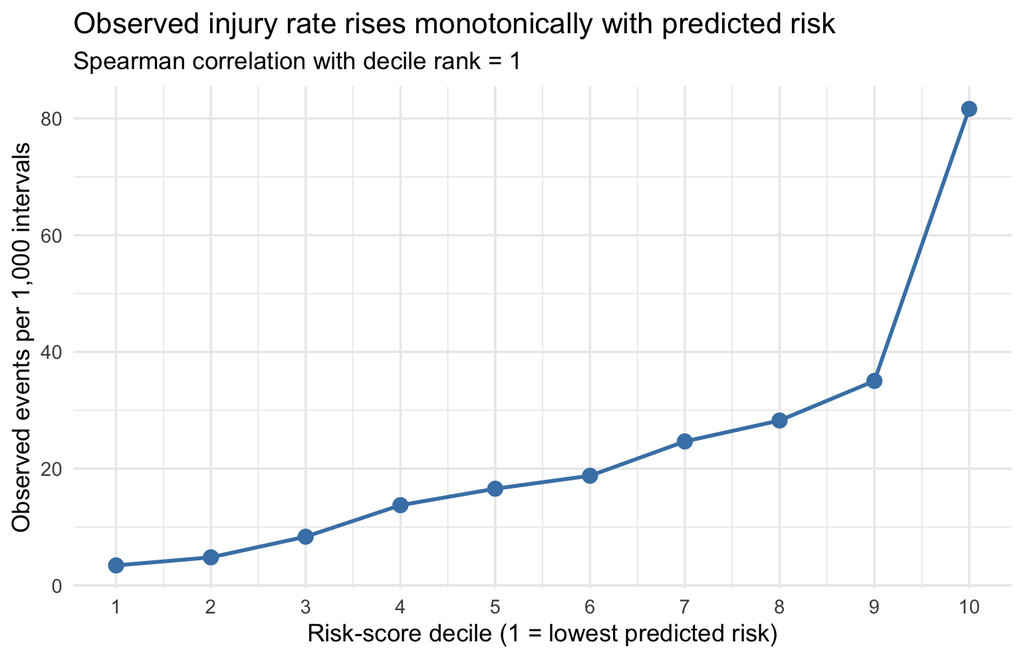

```r
fig_calib <- ggplot(calib, aes(risk_group, event_rate_1k)) +
  geom_line(colour = "steelblue", linewidth = 0.9) +
  geom_point(colour = "steelblue", size = 3) +
  scale_x_continuous(breaks = 1:10) +
  labs(title = "Observed injury rate rises monotonically with predicted risk",
       subtitle = paste0("Spearman correlation with decile rank = ", round(mono, 3)),
       x = "Risk-score decile (1 = lowest predicted risk)",
       y = "Observed events per 1,000 intervals") +
  theme_minimal(base_size = 12)

fig_calib
```

```r
domain_map <- tribble(
  ~term,                            ~domain,          ~label,
  "z_ROLLING_LOAD_7D",              "Workload",       "Acute on-court load (7d)",
  "z_ROLLING_LOAD_28D",             "Workload",       "Chronic on-court load (28d)",
  "z_ROLLING_GAMES_7D",             "Workload",       "Acute games played (7d)",
  "z_ROLLING_DIST_7D",              "Workload",       "Acute travel load (7d)",
  "z_ROLLING_DIST_28D",             "Workload",       "Chronic travel load (28d)",
  "z_SEASON_CUMULATIVE_DIST",       "Workload",       "Season cumulative travel",
  "z_PREV_GAME_DISTANCE",           "Workload",       "In-game load, last game *",
  "z_PREV_2GAME_DISTANCE",          "Workload",       "In-game load, 2 games back",
  "z_ROLLING_B2B_7D",               "Schedule",       "Acute back-to-back dose (7d)",
  "z_ROLLING_B2B_28D",              "Schedule",       "Chronic back-to-back dose (28d)",
  "z_PLAYER_ROAD_TRIP_GAME_NUMBER", "Schedule",       "Road-trip game number",
  "z_TEAM_DAYS_REST",               "Schedule",       "Team days rest",
  "z_IS_B2B",                       "Schedule",       "Back-to-back (point-in-time) *",
  "IS_PLAYER_ROAD_TRIP",            "Schedule",       "On road trip (point-in-time) *",
  "z_SEASONS_IN_LEAGUE",            "Player context", "Experience (seasons)",
  "I(z_SEASONS_IN_LEAGUE^2)",       "Player context", "Experience squared (inverted-U)",
  "z_CAREER_GAMES_MISSED",          "Player context", "Career games missed (durability)",
  "z_PRIOR_EPISODES_SEASON",        "Player context", "Prior injury episodes this season",
  "RECENT_RETURN",                  "Player context", "Recently returned (<=14d) *",
  "z_PCT_THROUGH_SEASON",           "Player context", "Season progress",
  "IS_POST_ALLSTAR",                "Player context", "Post-All-Star phase",
  "PLAYED_PRESEASON",               "Player context", "Played pre-season",
  "z_HEIGHT_INCHES",                "Player context", "Height",
  "z_WEIGHT",                       "Player context", "Weight"
)

hr_tab <- tidy(m3, exponentiate = TRUE, conf.int = TRUE) %>%
  select(term, HR = estimate, conf.low, conf.high, p.value) %>%
  left_join(domain_map, by = "term") %>%
  mutate(domain  = factor(domain, levels = c("Workload", "Schedule", "Player context")),
         across(c(HR, conf.low, conf.high), ~ round(.x, 3))) %>%
  arrange(domain, desc(abs(log(HR)))) %>%
  mutate(p.value = fmt_p(p.value)) %>%
  select(domain, label, HR, conf.low, conf.high, p.value)

show_tbl(hr_tab, "Final hazard ratios (Model 3), by domain - * = selection-biased")
```

Final hazard ratios (Model 3), by domain - * = selection-biased

| domain | label | HR | conf.low | conf.high | p.value |
| --- | --- | --- | --- | --- | --- |
| Workload | In-game load, last game * | 0.467 | 0.431 | 0.506 | 4.11e-78 |
| Workload | Chronic on-court load (28d) | 2.109 | 1.915 | 2.324 | 1.32e-51 |
| Workload | Acute games played (7d) | 2.046 | 1.863 | 2.247 | 1.04e-50 |
| Workload | In-game load, 2 games back | 1.515 | 1.407 | 1.630 | 2.05e-28 |
| Workload | Chronic travel load (28d) | 0.889 | 0.840 | 0.941 | 4.77e-05 |
| Workload | Season cumulative travel | 1.077 | 0.991 | 1.170 | 0.080 |
| Workload | Acute on-court load (7d) | 0.963 | 0.845 | 1.096 | 0.565 |
| Workload | Acute travel load (7d) | 1.037 | 0.992 | 1.083 | 0.107 |
| Schedule | On road trip (point-in-time) * | 0.805 | 0.718 | 0.902 | 1.91e-04 |
| Schedule | Back-to-back (point-in-time) * | 0.829 | 0.780 | 0.881 | 1.22e-09 |
| Schedule | Team days rest | 0.870 | 0.783 | 0.966 | 0.009 |
| Schedule | Acute back-to-back dose (7d) | 0.881 | 0.844 | 0.920 | 6.19e-09 |
| Schedule | Chronic back-to-back dose (28d) | 0.886 | 0.842 | 0.932 | 3.05e-06 |
| Schedule | Road-trip game number | 1.030 | 0.979 | 1.084 | 0.253 |
| Player context | Post-All-Star phase | 2.132 | 1.583 | 2.872 | 6.26e-07 |
| Player context | Season progress | 0.550 | 0.436 | 0.694 | 4.78e-07 |
| Player context | Prior injury episodes this season | 1.212 | 1.161 | 1.264 | 1.12e-18 |
| Player context | Career games missed (durability) | 1.158 | 1.079 | 1.243 | 4.56e-05 |
| Player context | Recently returned (<=14d) * | 0.888 | 0.801 | 0.985 | 0.024 |
| Player context | Experience (seasons) | 1.110 | 1.008 | 1.223 | 0.035 |
| Player context | Played pre-season | 0.920 | 0.805 | 1.051 | 0.221 |
| Player context | Experience squared (inverted-U) | 0.952 | 0.912 | 0.993 | 0.022 |
| Player context | Height | 1.026 | 0.952 | 1.106 | 0.500 |
| Player context | Weight | 0.994 | 0.921 | 1.072 | 0.868 |

```r
write.csv(hr_tab, file.path(BASE, "final_hazard_ratios_model3.csv"), row.names = FALSE)
```

## 5.1 What it shows

Concordance is 0.7375 (95% CI 0.728-0.747), and the risk score orders observed hazard almost perfectly across deciles (Spearman 1). The model reliably sorts high-risk from low-risk intervals even though it cannot state an absolute probability. For an operational use case, who should be managed this week, ranking is the suitable.

# 6 Stage 5 - Recurrent events and frailty

Feeds article 2.6, 3.6 and Appendix B.4.

Model 3 counts only first new injuries, which throws information away: players get hurt repeatedly and that repetition is what the applied literature cares about most. Rather than pick one recurrent-events model and hope, I fit three that assume different things.

- Andersen-Gill - every onset counts, common baseline, marginal. “What raises the hazard of any injury onset?”
- PWP gap-time - baseline stratified by event order, clock reset after each event. “Is a second injury different from a first?”
- Shared frailty - per-player random intercept. Its variance θ is a single-number measure of unobserved proneness, which is the Martin
  2021. claim made testable.

```r
m3_ag <- fit_cox(m3_terms, lhs = "Surv(t_start, t_stop, event_recurrent)")

ag_compare <- full_join(
  tidy(m3,    exponentiate = TRUE) %>% select(term, HR_new_injury = estimate),
  tidy(m3_ag, exponentiate = TRUE) %>% select(term, HR_all_injury = estimate),
  by = "term"
) %>%
  mutate(across(where(is.numeric), ~ round(.x, 3)))

show_tbl(ag_compare, "Primary (new injury) vs Andersen-Gill (all injury)")
```

Primary (new injury) vs Andersen-Gill (all injury)

| term | HR_new_injury | HR_all_injury |
| --- | --- | --- |
| z_ROLLING_LOAD_7D | 0.963 | 0.947 |
| z_ROLLING_LOAD_28D | 2.109 | 1.780 |
| z_ROLLING_GAMES_7D | 2.046 | 1.954 |
| z_ROLLING_DIST_7D | 1.037 | 1.065 |
| z_ROLLING_DIST_28D | 0.889 | 0.879 |
| z_SEASON_CUMULATIVE_DIST | 1.077 | 1.010 |
| z_PREV_GAME_DISTANCE | 0.467 | 0.542 |
| z_PREV_2GAME_DISTANCE | 1.515 | 1.475 |
| z_IS_B2B | 0.829 | 0.731 |
| z_ROLLING_B2B_7D | 0.881 | 0.863 |
| z_ROLLING_B2B_28D | 0.886 | 0.860 |
| z_PLAYER_ROAD_TRIP_GAME_NUMBER | 1.030 | 1.017 |
| z_TEAM_DAYS_REST | 0.870 | 0.656 |
| IS_PLAYER_ROAD_TRIP | 0.805 | 0.823 |
| z_SEASONS_IN_LEAGUE | 1.110 | 1.173 |
| I(z_SEASONS_IN_LEAGUE^2) | 0.952 | 0.947 |
| z_CAREER_GAMES_MISSED | 1.158 | 1.098 |
| z_PRIOR_EPISODES_SEASON | 1.212 | 1.228 |
| RECENT_RETURN | 0.888 | 1.999 |
| z_PCT_THROUGH_SEASON | 0.550 | 0.497 |
| IS_POST_ALLSTAR | 2.132 | 2.131 |
| PLAYED_PRESEASON | 0.920 | 0.793 |
| z_HEIGHT_INCHES | 1.026 | 1.033 |
| z_WEIGHT | 0.994 | 0.991 |

```r
# PWP gap-time: within each player-season, ep_order counts which spell this is, and
# the clock restarts at each event so "time" becomes games since the last injury.
pwp <- cox %>%
  arrange(SEASON, PLAYER_ID, t_stop) %>%
  group_by(SEASON, PLAYER_ID) %>%
  mutate(ep_order = 1L + cumsum(dplyr::lag(event_recurrent, default = 0L))) %>%
  group_by(SEASON, PLAYER_ID, ep_order) %>%
  mutate(gap_stop  = row_number(),
         gap_start = gap_stop - 1L) %>%
  ungroup() %>%
  mutate(ep_order_capped = factor(pmin(ep_order, 3L), levels = 1:3,
                                  labels = c("1st", "2nd", "3rd+")))

stopifnot(all(pwp$gap_stop > pwp$gap_start), all(pwp$gap_start >= 0))

# Drop prior-episode covariates: the event-order strata and the reset clock already show "how many prior injuries" and "how long since"
pwp_terms <- setdiff(m3_terms, c("z_PRIOR_EPISODES_SEASON", "RECENT_RETURN"))

pwp_fit <- coxph(
  as.formula(paste0("Surv(gap_start, gap_stop, event_recurrent) ~ ",
                    paste(pwp_terms, collapse = " + "),
                    " + strata(SEASON, ep_order_capped) + cluster(PLAYER_ID)")),
  data = pwp, ties = "efron"
)

pwp %>%
  group_by(ep_order_capped) %>%
  summarise(rows = n(), events = sum(event_recurrent),
            `Rate per 1,000` = round(1000 * events / rows, 1), .groups = "drop") %>%
  show_tbl("Events by injury-spell stratum")
```

Events by injury-spell stratum

| ep_order_capped | rows | events | Rate per 1,000 |
| --- | --- | --- | --- |
| 1st | 106671 | 1743 | 16.3 |
| 2nd | 36617 | 1175 | 32.1 |
| 3rd+ | 32914 | 2243 | 68.1 |

### 6.0.1 What the spell strata do to the baseline

`strata(SEASON, ep_order_capped)` is the part of this model I find most informative, and it is easy to skim past because it produces no coefficient at all. Stratifying tells the model to fit a separate baseline hazard for a player’s 1st, 2nd and 3rd-or-later spell, while sharing the covariate effects across them. Nothing about being on your third injury of the season is charged to a workload term; it is absorbed into the shape of the baseline. So if the baselines separate, that is recurrence risk showing up in a place no covariate can explain away.

They separate a lot.

```r
GAP_AT <- 10   # read the baselines at a common gap-time: 10 games back from injury

pwp_base <- basehaz(pwp_fit, centered = FALSE) %>% as_tibble() %>%
  mutate(Spell = case_when(grepl("1st", strata) ~ "1st",
                           grepl("2nd", strata) ~ "2nd",
                           grepl("3rd", strata) ~ "3rd+")) %>%
  filter(!is.na(Spell), time <= GAP_AT) %>%
  group_by(strata, Spell) %>% summarise(H = max(hazard), .groups = "drop") %>%
  group_by(Spell) %>% summarise(H = mean(H), .groups = "drop") %>%   # average over seasons
  mutate(`Baseline cumulative hazard` = round(H, 4),
         `Relative to 1st spell` = round(H / H[Spell == "1st"], 2)) %>%
  select(-H)
show_tbl(pwp_base, paste0("Baseline hazard by injury spell, at gap-time ", GAP_AT,
                          " games (covariate effects held equal)"))
```

Baseline hazard by injury spell, at gap-time 10 games (covariate effects held equal)

| Spell | Baseline cumulative hazard | Relative to 1st spell |
| --- | --- | --- |
| 1st | 0.207 | 1.00 |
| 2nd | 0.380 | 1.84 |
| 3rd+ | 0.584 | 2.83 |

```r
esc2 <- pwp_base$`Relative to 1st spell`[pwp_base$Spell == "2nd"]
esc3 <- pwp_base$`Relative to 1st spell`[pwp_base$Spell == "3rd+"]

# Crude (unadjusted) rates for the same strata, so the prose can compare how much of
# the escalation the covariates actually absorb.
crude <- pwp %>% group_by(ep_order_capped) %>%
  summarise(r = round(1000 * sum(event_recurrent) / n(), 1), .groups = "drop")
crude_1st <- crude$r[crude$ep_order_capped == "1st"]
crude_3rd <- crude$r[crude$ep_order_capped == "3rd+"]
```

Ten games after returning, and holding every workload, schedule and context covariate equal, a player in their second spell carries 1.84x the baseline hazard of a player in their first, and a player in their third or later spell carries 2.83x. The unadjusted picture is steeper still. Crude event rates go from 16.3 per 1,000 intervals in a first spell to 68.1 in a third, an escalation of 4.2x against the 2.83x that survives adjustment. So the covariates do absorb a real share of it, roughly 32%: players on their third injury of a season are carrying heavier workloads and worse schedules, and the model can see that. What it cannot see is the remaining 2.83x, which sits in the baseline where no covariate reaches it.

That is the clearest statement this thesis can make of a finding the injury-epidemiology literature has reported repeatedly: previous injury is among the strongest predictors of the next one (Fulton et al. 2014; Hägglund et al. 2006), and in the NBA specifically Eftekhari et al. (2022) found that 81.4% of players who sustained a hamstring injury went on to sustain a subsequent injury in the same or following season. The practical reading is uncomfortable but simple: the single largest change in a player’s risk profile is having already been injured once, and it is a change no amount of load management shows up as, because it is not carried by the load covariates at all.

```r
#a random intercept per player.
frail_fit <- coxme(
  as.formula(paste0("Surv(t_start, t_stop, event_recurrent) ~ ",
                    paste(m3_terms, collapse = " + "),
                    " + strata(SEASON) + (1 | PLAYER_ID)")),
  data = cox, ties = "efron"
)

theta    <- as.numeric(unlist(frail_fit$vcoef))[1]
sd_frail <- sqrt(theta)
frail_fit
```

```
#> Cox mixed-effects model fit by maximum likelihood
#>   Data: cox
#>   events, n = 5089, 166703 (9499 observations deleted due to missingness)
#>   Iterations= 24 151
#>                     NULL Integrated   Fitted
#> Log-likelihood -30386.94  -27903.74 -27366.8
#>
#>                     Chisq     df p     AIC     BIC
#> Integrated loglik 4966.40  25.00 0 4916.40 4753.03
#>  Penalized loglik 6040.29 425.05 0 5190.19 2412.56
#>
#> Model:  as.formula(paste0("Surv(t_start, t_stop, event_recurrent) ~ ",      paste(m3_terms, collapse = " + "), " + strata(SEASON) + (1 | PLAYER_ID)"))
#> Fixed coefficients
#>                                       coef exp(coef)   se(coef)      z       p
#> z_ROLLING_LOAD_7D              -0.07371654 0.9289350 0.05964678  -1.24 2.2e-01
#> z_ROLLING_LOAD_28D              0.57384218 1.7750741 0.03845113  14.92 0.0e+00
#> z_ROLLING_GAMES_7D              0.68563635 1.9850346 0.04797439  14.29 0.0e+00
#> z_ROLLING_DIST_7D               0.05711136 1.0587737 0.01887488   3.03 2.5e-03
#> z_ROLLING_DIST_28D             -0.12817294 0.8797012 0.02656619  -4.82 1.4e-06
#> z_SEASON_CUMULATIVE_DIST        0.04251047 1.0434270 0.03452635   1.23 2.2e-01
#> z_PREV_GAME_DISTANCE           -0.63928961 0.5276671 0.02968889 -21.53 0.0e+00
#> z_PREV_2GAME_DISTANCE           0.34782914 1.4159903 0.03140633  11.08 0.0e+00
#> z_IS_B2B                       -0.30480208 0.7372693 0.01789540 -17.03 0.0e+00
#> z_ROLLING_B2B_7D               -0.14592455 0.8642229 0.01932050  -7.55 4.3e-14
#> z_ROLLING_B2B_28D              -0.14214552 0.8674950 0.02256091  -6.30 3.0e-10
#> z_PLAYER_ROAD_TRIP_GAME_NUMBER  0.01472967 1.0148387 0.02418306   0.61 5.4e-01
#> z_TEAM_DAYS_REST               -0.40938655 0.6640575 0.03065504 -13.35 0.0e+00
#> IS_PLAYER_ROAD_TRIP            -0.18600439 0.8302700 0.05048402  -3.68 2.3e-04
#> z_SEASONS_IN_LEAGUE             0.38381813 1.4678785 0.04860333   7.90 2.9e-15
#> I(z_SEASONS_IN_LEAGUE^2)       -0.10488053 0.9004321 0.01853644  -5.66 1.5e-08
#> z_CAREER_GAMES_MISSED          -0.04158252 0.9592702 0.03683527  -1.13 2.6e-01
#> z_PRIOR_EPISODES_SEASON         0.08557544 1.0893437 0.01353648   6.32 2.6e-10
#> RECENT_RETURN                   0.57649816 1.7797949 0.03620222  15.92 0.0e+00
#> z_PCT_THROUGH_SEASON           -0.63724108 0.5287492 0.10170088  -6.27 3.7e-10
#> IS_POST_ALLSTAR                 0.73782020 2.0913718 0.13944904   5.29 1.2e-07
#> PLAYED_PRESEASON               -0.26312026 0.7686495 0.05884679  -4.47 7.8e-06
#> z_HEIGHT_INCHES                 0.04963349 1.0508859 0.03973638   1.25 2.1e-01
#> z_WEIGHT                       -0.03226384 0.9682511 0.04070545  -0.79 4.3e-01
#>
#> Random effects
#>  Group     Variable  Std Dev   Variance
#>  PLAYER_ID Intercept 0.5412166 0.2929154
```

A θ on its own is uninterpretable: it says how much players differ in what I could not measure, not how much of the original difference I removed. So I refit with the blocks added one at a time from nothing, all on the same rows, otherwise the variances are not comparable.

```r
# Common row set, so theta is comparable across specifications.
need_f <- gsub("I\\(|\\^2\\)", "", unique(m3_terms))
d_f <- cox %>% filter(if_all(all_of(intersect(need_f, names(cox))), ~ !is.na(.)))

theta_of <- function(terms) {
  rhs <- if (length(terms))
    paste(paste(terms, collapse = " + "), "+ strata(SEASON) + (1 | PLAYER_ID)")
  else "strata(SEASON) + (1 | PLAYER_ID)"
  fit <- coxme(as.formula(paste("Surv(t_start, t_stop, event_recurrent) ~", rhs)),
               data = d_f, ties = "efron")
  as.numeric(unlist(fit$vcoef))[1]
}

theta_steps <- c(`No covariates (baseline)` = theta_of(character(0)),
                 `+ Workload`               = theta_of(m1_terms),
                 `+ Schedule congestion`    = theta_of(m2_terms),
                 `+ Player context (full)`  = theta_of(m3_terms))

frailty_tab <- tibble(
  Model = names(theta_steps),
  theta = round(theta_steps, 3),
  `SD (log hazard)` = round(sqrt(theta_steps), 3),
  `Hazard, +1 SD of proneness` = round(exp(sqrt(theta_steps)), 2),
  `90th vs 10th percentile` = round(exp(2 * qnorm(0.9) * sqrt(theta_steps)), 2)
)
pct_absorbed <- round(100 * (theta_steps[1] - theta_steps[4]) / theta_steps[1])
show_tbl(frailty_tab, paste0("Between-player heterogeneity as covariates are added (",
                             pct_absorbed, "% of the baseline variance absorbed)"))
```

Between-player heterogeneity as covariates are added (70% of the baseline variance absorbed)

Model

theta

SD (log hazard)

Hazard, +1 SD of proneness

90th vs 10th percentile

No covariates (baseline)

0.963

0.981

2.67

12.36

- Workload

0.756

0.870

2.39

9.29

- Schedule congestion

0.640

0.800

2.23

7.78

- Player context (full)

0.293

0.541

1.72

4.00

```r
headline <- c("z_ROLLING_LOAD_28D", "z_ROLLING_LOAD_7D",
              "z_ROLLING_GAMES_7D", "z_CAREER_GAMES_MISSED", "z_SEASONS_IN_LEAGUE",
              "z_TEAM_DAYS_REST", "z_IS_B2B", "z_PRIOR_EPISODES_SEASON", "RECENT_RETURN")

hr_from <- function(cf, nm) if (nm %in% names(cf)) round(exp(cf[[nm]]), 3) else NA_real_

compare <- tibble(
  term       = headline,
  HR_AG      = map_dbl(headline, ~ hr_from(coef(m3_ag),    .x)),
  HR_PWP     = map_dbl(headline, ~ hr_from(coef(pwp_fit),  .x)),
  HR_frailty = map_dbl(headline, ~ hr_from(fixef(frail_fit), .x))
)

show_tbl(compare, "Cross-model comparison - AG (marginal) vs PWP (spell strata) vs frailty (conditional)")
```

Cross-model comparison - AG (marginal) vs PWP (spell strata) vs frailty (conditional)

| term | HR_AG | HR_PWP | HR_frailty |
| --- | --- | --- | --- |
| z_ROLLING_LOAD_28D | 1.780 | 1.848 | 1.775 |
| z_ROLLING_LOAD_7D | 0.947 | 0.920 | 0.929 |
| z_ROLLING_GAMES_7D | 1.954 | 1.953 | 1.985 |
| z_CAREER_GAMES_MISSED | 1.098 | 1.113 | 0.959 |
| z_SEASONS_IN_LEAGUE | 1.173 | 1.166 | 1.468 |
| z_TEAM_DAYS_REST | 0.656 | 0.597 | 0.664 |
| z_IS_B2B | 0.731 | 0.713 | 0.737 |
| z_PRIOR_EPISODES_SEASON | 1.228 | NA | 1.089 |
| RECENT_RETURN | 1.999 | NA | 1.780 |

## 6.1 What it shows

The headline workload effects hold their shape across all three, the chronic-load result is not an artefact of how I chose to handle recurrence.

The frailty variance θ = 0.293 is the most interesting number in this section, but only once it is read against the baseline. With no covariates at all, θ is 0.963, which puts the 90th percentile of injury-proneness at 12.4x the hazard of the 10th. With the full covariate set that spread falls to 4x. The model absorbs 70% of the between-player variance.

Player context does most of that work, taking θ from 0.64 to 0.293, more than workload and schedule combined. Which is what should happen: career games missed, tenure and prior-episode history are player-level attributes, so they are the only terms with real purchase on between-player differences. Workload moves around within a player across a season.

Worth setting the residual against something measured. One SD of unmeasured proneness multiplies hazard by 1.72; one SD of chronic load by 2.109. The biggest thing I measure is bigger than the biggest thing I miss. What is left is a real 4x spread that public data does not reach, which is a limit rather than a failure.

`CAREER_GAMES_MISSED` is the instructive divergence: 1.098 under AG, 0.959 under frailty. Not a contradiction, two questions. AG is marginal (across the population, more games missed means higher risk); frailty is conditional (holding a player’s own proneness fixed, it adds nothing). Career games missed is largely a proxy for the frailty term, so once frailty is estimated the proxy has no work left.

# 7 Stage 6 - Mechanism split and hazard trajectory

Feeds article 2.6, 3.4 and 3.5. This is the secondary, exploratory aim: comparing workload associations across injury mechanisms.

This is the stage that tests my hypothesis hardest, and where I most expected to be wrong.

The negative control. If workload genuinely causes injury, its effect should depend on injury type: strong for overuse injuries, weaker for injuries that are essentially random contact events. If instead workload predicts every injury type equally, including a finger fracture from a loose ball, then what I am measuring is not fatigue but exposure: high-load players are on court more, so more things happen to them.

The tiers are cut on mechanism, following the IOC consensus statement (Bahr et al. 2020), which asks for mechanism to be recorded as acute, repetitive, or a mix of the two, and explicitly warns against a simple sudden/gradual dichotomy.

The repetitive tier is reported in **two columns**, and that split turned out to matter more than anything else in this stage. Only about a fifth of it is a pathology anyone actually named; the rest is symptom text. A column of four, then:

1. **Overuse, pathology reported** - the report names an overuse pathology: tendinopathy, plantar fasciopathy, bursitis, stress fracture or stress reaction. It is a reported pathology, not a clinical diagnosis. If accumulated workload causes injury, this is where the effect belongs.
2. **Overuse, symptom only** - the same mechanism label, but the report records only “soreness”, “tightness” or “spasms” with no diagnosis attached. Whether these are incident pathology or a precautionary rest decision written down as soreness is exactly the question, and keeping them separate is what lets the table answer it.
3. **Acute non-contact** - a discrete event that fatigue can plausibly set up: strains, sprains, and non-contact tears. The IOC’s “mixed” case, an acute failure of a cumulatively loaded tissue.
4. **Acute impact** - external energy transfer: contusions, lacerations, concussion, and fractures or dislocations at contact-prone sites. Accumulated workload is an unlikely cause of a jammed finger or a facial laceration, so this is the negative control. It shares the exposure and selection that act on the other tiers (a player has to be on court to be hit) but has the weakest plausible fatigue pathway. Fatigue could still raise collision risk at the margin, so the control can show that a term fails to discriminate between mechanisms, not that fatigue plays no part.

Only the overuse tier splits this way. My classifier sends all vague symptom text to “repetitive” by construction, so acute non-contact and acute impact are already about 95% named pathology and there is nothing to separate; splitting them would be a distinction without a difference, on strata far too small to fit.

A null result on the control would support a causal reading of the workload effect. A positive result detects confounding. So the control is doing its job either way, and the reader should judge it on whether it can detect bias, not on whether it comes out empty.

If impact injuries are mostly exposure, the impact column approximates the exposure-and-selection association on its own, and a covariate whose estimate does not exceed it gives no sign of a mechanism-specific effect. A ratio of two hazard ratios is not a test of that, and nor is one tier being significant while another is not, so each comparison is estimated directly: the two outcomes are stacked in one model and the difference gets its own confidence interval and p-value. The pre-specified comparison is all overuse against the control; the split by reported pathology came after seeing that pooled result, so anything that rests on it is exploratory.

Contact versus non-contact is not always recoverable from a public injury report: an ankle sprain can be landing awkwardly or landing on someone’s foot, and the report says only “Left Ankle; Sprain”. I assign each episode on the balance of the recorded pathology and the site, so the control tier is indicative rather than exact.

The trajectory. `basehaz()` on Model 3 reads the baseline hazard directly: when in a season risk rises for a player at the reference level of every covariate, conditional on the fitted model.

```r
# Mechanism models use the EXACT Model 3 specification (m3_terms): one specification,
# four outcomes, so every column is directly comparable to Model 3 and to each other.
#
# The repetitive tier is split.
named_path <- !cox$INJURY_TISSUE %in% c("non_specific", "not_recorded")
cox$ev_rep_named <- as.integer(cox$event_repetitive == 1 &  named_path)
cox$ev_rep_vague <- as.integer(cox$event_repetitive == 1 & !named_path)

fit_outcome <- function(outcome, terms) {
  coxph(as.formula(paste0("Surv(t_start, t_stop, ", outcome, ") ~ ",
                          paste(terms, collapse = " + "), " + ", rhs_tail)),
        data = cox, ties = "efron")
}

m_rep_named <- fit_outcome("ev_rep_named",     m3_terms)  # overuse, pathology reported
m_rep_vague <- fit_outcome("ev_rep_vague",     m3_terms)  # symptom report only
m_load      <- fit_outcome("event_acute_nc",   m3_terms)  # acute non-contact
m_impact    <- fit_outcome("event_acute_imp",  m3_terms)  # acute impact = the control
m_soft      <- fit_outcome("event_repetitive", m3_terms)  # pooled overuse (the pre-specified tier)

m_soft_recurrent   <- fit_outcome("event_repetitive_recurrent", m3_terms)
m_load_recurrent   <- fit_outcome("event_acute_nc_recurrent",   m3_terms)
m_impact_recurrent <- fit_outcome("event_acute_imp_recurrent",  m3_terms)

mech_terms <- tribble(
  ~term,                     ~label,
  "z_ROLLING_LOAD_28D",      "Chronic load (28d)",
  "z_ROLLING_LOAD_7D",       "Acute load (7d)",
  "z_ROLLING_GAMES_7D",      "Games played (7d)",
  "z_PREV_2GAME_DISTANCE",   "In-game load, 2 games back",
  "z_PRIOR_EPISODES_SEASON", "Prior injury episodes",
  "z_CAREER_GAMES_MISSED",   "Career games missed",
  "IS_POST_ALLSTAR",         "Post-All-Star phase")

mods <- list(m_rep_named, m_rep_vague, m_load, m_impact)
nms  <- c("Overuse (pathology reported)", "Overuse (symptom only)", "Acute non-contact",
          "Acute impact (control)")

# ── Direct contrasts between tiers ──
# A ratio of two hazard ratios is not a test of whether they differ, and nor is one
# tier being significant while another is not. So each comparison is estimated in one
# stacked model: the two outcomes are stacked, every term is interacted with the
# outcome, each outcome keeps its own season baselines, and the player-clustered
# covariance gives the difference its own standard error. Point estimates are
# identical to the separate tier fits above.
tier_contrast <- function(evA, evB, labA, labB, terms = m3_terms,
                          focus = mech_terms$term, data = cox) {
  keep <- unique(c("t_start", "t_stop", "SEASON", "PLAYER_ID",
                   gsub("^I\\((.*)\\^2\\)$", "\\1", terms)))
  st <- bind_rows(data[keep] %>% mutate(mtier = labA, ev = data[[evA]]),
                  data[keep] %>% mutate(mtier = labB, ev = data[[evB]])) %>%
    mutate(mtier = factor(mtier, levels = c(labA, labB)))
  fit <- coxph(as.formula(paste0("Surv(t_start, t_stop, ev) ~ ",
                                 paste0("(", terms, "):mtier", collapse = " + "),
                                 " + strata(SEASON, mtier) + cluster(PLAYER_ID)")),
               data = st, ties = "efron")
  b <- coef(fit); V <- vcov(fit)
  # R names the first interaction term:mtierX and the later ones mtierX:term
  find <- function(tm, lab) {
    nm <- names(b)[gsub("[()]", "", names(b)) %in%
                     c(paste0(tm, ":mtier", lab), paste0("mtier", lab, ":", tm))]
    stopifnot(length(nm) == 1); nm
  }
  map_dfr(focus, function(tm) {
    a <- find(tm, labA); z <- find(tm, labB)
    d <- b[[a]] - b[[z]]; se <- sqrt(V[a, a] + V[z, z] - 2 * V[a, z])
    tibble(term = tm, ratio = exp(d), lo = exp(d - 1.96 * se), hi = exp(d + 1.96 * se),
           p = 2 * pnorm(-abs(d / se)))
  })
}

ct_rep   <- tier_contrast("ev_rep_named",     "event_acute_imp", "reported",   "impact")
ct_nc    <- tier_contrast("event_acute_nc",   "event_acute_imp", "noncontact", "impact")
ct_pool  <- tier_contrast("event_repetitive", "event_acute_imp", "overuse",    "impact")
ct_vague <- tier_contrast("ev_rep_named",     "ev_rep_vague",    "reported",   "symptom")

# Cells: HR (95% CI) from each tier's robust covariance; the two ratio columns are the
# joint-model contrasts against the control, with their own CI and p-value.
ci_cell <- function(fit, tm) {
  b <- coef(fit)[[tm]]; se <- sqrt(vcov(fit)[tm, tm])
  sprintf("%.2f (%.2f-%.2f)", exp(b), exp(b - 1.96 * se), exp(b + 1.96 * se))
}
ratio_cell <- function(ct, tm) {
  r <- ct[ct$term == tm, ]
  sprintf("%.2f (%.2f-%.2f), p = %s", r$ratio, r$lo, r$hi, fmt_p(r$p))
}
# Inline helper for the prose below: "1.58 (95% CI 1.05-2.40, p = 0.030)"
ratio_txt <- function(ct, tm) {
  r <- ct[ct$term == tm, ]
  sprintf("%.2f (95%% CI %.2f-%.2f, p = %s)", r$ratio, r$lo, r$hi, fmt_p(r$p))
}
hr_ci_txt <- function(fit, tm) {
  b <- coef(fit)[[tm]]; se <- sqrt(vcov(fit)[tm, tm])
  sprintf("%.2f (95%% CI %.2f-%.2f)", exp(b), exp(b - 1.96 * se), exp(b + 1.96 * se))
}

# Built as character throughout: the p-value / concordance / event rows appended below
# are text, and bind_rows will not combine a numeric column with a character one.
mech_tab <- mech_terms %>%
  mutate(!!nms[1] := map_chr(term, ~ ci_cell(m_rep_named, .x)),
         !!nms[2] := map_chr(term, ~ ci_cell(m_rep_vague, .x)),
         !!nms[3] := map_chr(term, ~ ci_cell(m_load,      .x)),
         !!nms[4] := map_chr(term, ~ ci_cell(m_impact,    .x)),
         `Reported / control`    = map_chr(term, ~ ratio_cell(ct_rep, .x)),
         `Non-contact / control` = map_chr(term, ~ ratio_cell(ct_nc,  .x))) %>%
  select(` ` = label, all_of(nms), `Reported / control`, `Non-contact / control`)

acute_p <- map_chr(mods, ~ fmt_p(summary(.x)$coefficients["z_ROLLING_LOAD_7D", "Pr(>|z|)"]))

mech_tab <- bind_rows(
  mech_tab,
  tibble(` ` = "Acute load p-value", !!nms[1] := acute_p[1], !!nms[2] := acute_p[2],
         !!nms[3] := acute_p[3], !!nms[4] := acute_p[4],
         `Reported / control` = NA_character_, `Non-contact / control` = NA_character_),
  tibble(` ` = "Concordance (C)",
         !!nms[1] := as.character(round(summary(m_rep_named)$concordance[1], 3)),
         !!nms[2] := as.character(round(summary(m_rep_vague)$concordance[1], 3)),
         !!nms[3] := as.character(round(summary(m_load)$concordance[1], 3)),
         !!nms[4] := as.character(round(summary(m_impact)$concordance[1], 3)),
         `Reported / control` = NA_character_, `Non-contact / control` = NA_character_),
  # events entering each model, after the lagged terms' burn-in (Table 1 counts the
  # tier sizes before that burn-in, which is why these are slightly smaller)
  tibble(` ` = "Events in model",
         !!nms[1] := as.character(m_rep_named$nevent),
         !!nms[2] := as.character(m_rep_vague$nevent),
         !!nms[3] := as.character(m_load$nevent),
         !!nms[4] := as.character(m_impact$nevent),
         `Reported / control` = NA_character_, `Non-contact / control` = NA_character_))

show_tbl(mech_tab, "Mechanism split (IOC axis): HR per SD (95% CI); ratio columns are joint-model contrasts against the impact control")
```

Mechanism split (IOC axis): HR per SD (95% CI); ratio columns are joint-model contrasts against the impact control

|  | Overuse (pathology reported) | Overuse (symptom only) | Acute non-contact | Acute impact (control) | Reported / control | Non-contact / control |
| --- | --- | --- | --- | --- | --- | --- |
| Chronic load (28d) | 1.78 (1.36-2.32) | 1.98 (1.70-2.31) | 2.28 (1.95-2.66) | 2.04 (1.63-2.55) | 0.87 (0.62-1.23), p = 0.432 | 1.12 (0.85-1.47), p = 0.434 |
| Acute load (7d) | 1.64 (1.17-2.30) | 0.82 (0.66-1.01) | 0.89 (0.72-1.11) | 1.03 (0.79-1.36) | 1.58 (1.05-2.40), p = 0.030 | 0.86 (0.61-1.22), p = 0.403 |
| Games played (7d) | 1.36 (1.05-1.75) | 2.29 (1.94-2.70) | 2.20 (1.89-2.55) | 1.83 (1.46-2.28) | 0.74 (0.53-1.04), p = 0.080 | 1.20 (0.92-1.57), p = 0.178 |
| In-game load, 2 games back | 1.11 (0.91-1.37) | 1.29 (1.14-1.46) | 1.88 (1.67-2.11) | 1.40 (1.19-1.66) | 0.80 (0.61-1.04), p = 0.095 | 1.34 (1.09-1.65), p = 0.006 |
| Prior injury episodes | 1.25 (1.15-1.36) | 1.27 (1.20-1.34) | 1.14 (1.08-1.21) | 1.20 (1.09-1.32) | 1.04 (0.93-1.17), p = 0.483 | 0.96 (0.86-1.06), p = 0.374 |
| Career games missed | 1.20 (1.02-1.42) | 1.19 (1.07-1.31) | 1.07 (0.97-1.18) | 1.27 (1.09-1.48) | 0.95 (0.77-1.16), p = 0.602 | 0.84 (0.70-1.01), p = 0.063 |
| Post-All-Star phase | 0.52 (0.16-1.67) | 1.81 (1.09-3.00) | 2.33 (1.48-3.67) | 2.94 (1.38-6.26) | 0.18 (0.04-0.72), p = 0.016 | 0.79 (0.32-1.98), p = 0.617 |
| Acute load p-value | 0.004 | 0.065 | 0.297 | 0.804 | NA | NA |
| Concordance (C) | 0.756 | 0.741 | 0.742 | 0.731 | NA | NA |
| Events in model | 424 | 1338 | 1424 | 588 | NA | NA |

```r
# The contrasts behind the prose, including the pre-specified pooled comparison.
mech_contrasts <- bind_rows(
  ct_pool  %>% mutate(Comparison = "All overuse vs impact control (pre-specified)"),
  ct_rep   %>% mutate(Comparison = "Overuse, pathology reported vs impact control"),
  ct_vague %>% mutate(Comparison = "Overuse, pathology reported vs symptom only"),
  ct_nc    %>% mutate(Comparison = "Acute non-contact vs impact control")) %>%
  filter(term %in% c("z_ROLLING_LOAD_7D", "z_ROLLING_LOAD_28D", "z_ROLLING_GAMES_7D")) %>%
  left_join(mech_terms, by = "term") %>%
  transmute(Comparison, Covariate = label, `Ratio of HRs` = sprintf("%.2f", ratio),
            `95% CI` = sprintf("%.2f-%.2f", lo, hi), p = fmt_p(p))

show_tbl(mech_contrasts, "Direct contrasts between tiers (joint model, player-clustered covariance)")
```

Direct contrasts between tiers (joint model, player-clustered covariance)

| Comparison | Covariate | Ratio of HRs | 95% CI | p |
| --- | --- | --- | --- | --- |
| All overuse vs impact control (pre-specified) | Chronic load (28d) | 0.94 | 0.73-1.22 | 0.660 |
| All overuse vs impact control (pre-specified) | Acute load (7d) | 0.94 | 0.67-1.31 | 0.720 |
| All overuse vs impact control (pre-specified) | Games played (7d) | 1.10 | 0.84-1.42 | 0.494 |
| Overuse, pathology reported vs impact control | Chronic load (28d) | 0.87 | 0.62-1.23 | 0.432 |
| Overuse, pathology reported vs impact control | Acute load (7d) | 1.58 | 1.05-2.40 | 0.030 |
| Overuse, pathology reported vs impact control | Games played (7d) | 0.74 | 0.53-1.04 | 0.080 |
| Overuse, pathology reported vs symptom only | Chronic load (28d) | 0.90 | 0.67-1.21 | 0.481 |
| Overuse, pathology reported vs symptom only | Acute load (7d) | 2.01 | 1.36-2.97 | 4.39e-04 |
| Overuse, pathology reported vs symptom only | Games played (7d) | 0.59 | 0.44-0.80 | 6.79e-04 |
| Acute non-contact vs impact control | Chronic load (28d) | 1.12 | 0.85-1.47 | 0.434 |
| Acute non-contact vs impact control | Acute load (7d) | 0.86 | 0.61-1.22 | 0.403 |
| Acute non-contact vs impact control | Games played (7d) | 1.20 | 0.92-1.57 | 0.178 |

```r
# Which terms genuinely differ between reported-pathology overuse and the control, read
# off the contrast CIs rather than asserted in the prose.
# lower-case only the first letter, so proper nouns such as All-Star survive
lbl <- function(tms) sub("^(.)", "\\L\\1", mech_terms$label[match(tms, mech_terms$term)], perl = TRUE)
rep_above <- lbl(ct_rep$term[ct_rep$lo > 1])
rep_below <- lbl(ct_rep$term[ct_rep$hi < 1])
rep_sentence <- paste0(
  if (length(rep_above)) paste0("Reading down the `Reported / control` column, ",
    if (length(rep_above) == 1) "the only term whose ratio has a 95% CI entirely above 1 is "
    else "the terms whose ratio has a 95% CI entirely above 1 are ",
    knitr::combine_words(rep_above), ". ")
  else "Reading down the `Reported / control` column, no term has a ratio whose 95% CI lies entirely above 1. ",
  if (length(rep_below)) paste0(sub("^(.)", "\\U\\1", knitr::combine_words(rep_below), perl = TRUE),
    if (length(rep_below) == 1) " is" else " are",
    " larger for impact injuries than for reported-pathology overuse, with a CI entirely below 1. ")
  else "",
  "For the remaining terms the contrast does not establish a difference either way.")
```

The two workload terms that dominate Model 3 are raised for every mechanism, the impact control included. Chronic load is 2.04 (95% CI 1.63-2.55) on impact injuries against 1.78 (95% CI 1.36-2.32) on overuse with a reported pathology, and recent games played is 1.83 (95% CI 1.46-2.28) on the control. Chronic load does not differ from the control in the direct contrasts: reported pathology against impact 0.87 (95% CI 0.62-1.23, p = 0.432), all overuse against impact 0.94 (95% CI 0.73-1.22, p = 0.660). A month of heavy load is an unlikely cause of a fractured finger, so the most economical reading is exposure and selection: players carrying heavy load are on court when a loose ball or a stray elbow arrives, and they are carrying it because they were fit enough to keep being selected. The control cannot rule a fatigue contribution out, since fatigue could slow a player’s reaction to contact. What it shows is that these terms do not discriminate between mechanisms.

Acute load behaves differently, but in one tier only. Holding chronic load and recent games equal, it is 1.64 (95% CI 1.17-2.30) for overuse where a pathology is reported, and not distinguishable from 1 in the other tiers: symptom-only 0.816, acute non-contact 0.893, and the control 1.035. Against the control the difference is 1.58 (95% CI 1.05-2.40, p = 0.030), and against symptom-only reports 2.01 (95% CI 1.36-2.97, p = 4.39e-04). The pre-specified comparison, all overuse against the control, shows no difference (0.94 (95% CI 0.67-1.31, p = 0.720)). The split by reported pathology was made after seeing that, so this is an exploratory pattern: consistent with a fatigue pathway in overuse injury where a pathology is named, not an identification of one.

One possible reason the pooled overuse tier shows nothing is measurement. About three quarters of it records only soreness, tightness or spasm, which may be precautionary rest written down as a symptom rather than incident pathology. Prior episodes stays strong in that column (1.272), so it tracks who the player is rather than what he did recently, and a player reporting soreness is plausibly already being managed, which would pull its load coefficients toward 1. If that is right, a surveillance system built on availability text will understate any workload association with overuse injury.

Reading down the `Reported / control` column, the only term whose ratio has a 95% CI entirely above 1 is acute load (7d). Post-All-Star phase is larger for impact injuries than for reported-pathology overuse, with a CI entirely below 1. For the remaining terms the contrast does not establish a difference either way. Prior injury episodes, for example, sits at 1.04 (95% CI 0.93-1.17, p = 0.483).

Discrimination is lowest for the control (0.731), against 0.756 for reported-pathology overuse and 0.742 for acute non-contact. The spread is narrow and I would not lean on it alone.

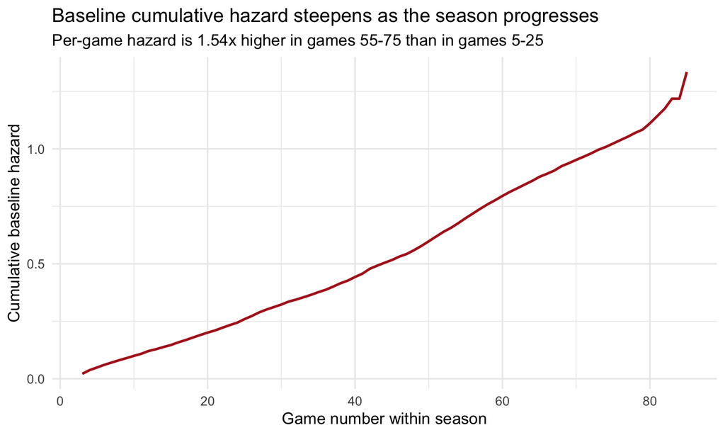

```r
# The baseline of Model 3 itself, i.e. all new injuries, which is what the article's
# "for an average player" describes. This previously read the pooled overuse tier.
attr(m3$terms, ".Environment") <- environment()   # see the note in the calibration chunk
traj <- basehaz(m3, centered = FALSE) %>%
  as_tibble() %>%
  rename(cum_haz = hazard, game_number = time) %>%
  group_by(game_number) %>%
  summarise(cum_haz = mean(cum_haz), .groups = "drop") %>%   # average across season strata
  arrange(game_number)

haz_at <- function(g) traj$cum_haz[which.min(abs(traj$game_number - g))]

early_rate <- (haz_at(25) - haz_at(5))  / 20   # per-game hazard, games 5-25
late_rate  <- (haz_at(75) - haz_at(55)) / 20   # per-game hazard, games 55-75

fig_traj <- ggplot(traj, aes(game_number, cum_haz)) +
  geom_line(colour = "firebrick", linewidth = 0.9) +
  labs(title = "Baseline cumulative hazard steepens as the season progresses",
       subtitle = paste0("Per-game hazard is ", sprintf("%.2f", late_rate / early_rate),
                         "x higher in games 55-75 than in games 5-25"),
       x = "Game number within season", y = "Cumulative baseline hazard") +
  theme_minimal(base_size = 12)

fig_traj
```

## 7.1 What it shows

The mechanism split revises my hypothesis rather than confirming it. The workload terms that dominate the model, chronic load and recent games played, are raised for every mechanism including impact injuries, which is the pattern exposure and selection would produce. Acute load, conditional on those, is raised only for overuse where a pathology is reported, and that difference from the control holds in a direct contrast; the pre-specified pooled comparison does not. I read the first as the main workload result and the second as an exploratory finding consistent with a fatigue pathway in that subset, not as a separately identified fatigue component.

The trajectory. For Model 3, per-game baseline hazard is 1.54 x higher in games 55–75 than in games 5–25.

This is a residual, conditional on the fitted covariates, not proof that nothing measured or unmeasured could explain it. Two things qualify it. The workload terms carrying the argument showed no detected change in relative effect across the season (Stage 3: chronic load and acute load are among the most clearly proportional terms), so the rise is in background risk rather than in how those terms act. But part of the late-season rise is already carried by a coefficient: the post-All-Star term is 2.132, and the baseline is what remains after it. The baseline rise and the post-All-Star term together describe the season dynamic; the baseline alone understates it.

# 8 Stage 7 - Out-of-sample validation

Feeds article 2.7 and 3.7.

Everything above is apparent performance, scored on the data it was fitted to, which is optimistic by construction. 24 covariates is ample opportunity to fit noise. Two hold-outs, chosen because they fail differently:

- Temporal split: train 2021-22 to 2024-25, test 2025-26. The operational question, and how a rolling tool would actually run.
- Player-grouped 5-fold CV: whole players held out. A random row split would put LeBron’s game 5 in training and game 6 in test, so the model could score well by memorising him.

Two safeguards: z-scores computed on training rows only, otherwise the test distribution leaks into training; and `strata(SEASON)` dropped, because a stratified model has no baseline for a season it never saw and discrimination needs only the linear predictor.

```r
zcols <- c("ROLLING_MIN_7D","ROLLING_MIN_28D","ACWR_MIN","ROLLING_GAMES_7D",
           "ROLLING_DIST_7D","ROLLING_DIST_28D","SEASON_CUMULATIVE_DIST","MIN",
           "PREV_GAME_MIN","PREV_2GAME_MIN",
           "ROLLING_LOAD_7D","ROLLING_LOAD_28D","ACWR_LOAD",
           "PREV_GAME_DISTANCE","PREV_2GAME_DISTANCE",
           "PREV_GAME_INTENSITY","PREV_2GAME_INTENSITY",
           "ROLLING_B2B_7D","ROLLING_B2B_28D","PLAYER_ROAD_TRIP_GAME_NUMBER",
           "TEAM_DAYS_REST","SEASONS_IN_LEAGUE","CAREER_GAMES_MISSED",
           "PRIOR_EPISODES_SEASON","PCT_THROUGH_SEASON","HEIGHT_INCHES","WEIGHT")

# primary = the reported load model; minutes = the same spec with minutes swapped in,
# validated out of sample as the robustness check (both on the new-injury outcome).
specs <- list(
  primary = list(outcome = "event", terms = c(paste0("z_", c("ROLLING_LOAD_7D","ROLLING_LOAD_28D","ROLLING_GAMES_7D","PREV_GAME_DISTANCE","PREV_2GAME_DISTANCE")),
                                              "z_ROLLING_DIST_7D","z_ROLLING_DIST_28D","z_SEASON_CUMULATIVE_DIST",
                                              schedule_added, context_added)),
  minutes = list(outcome = "event", terms = c(paste0("z_", c("ROLLING_MIN_7D","ROLLING_MIN_28D","ROLLING_GAMES_7D","PREV_GAME_MIN","PREV_2GAME_MIN")),
                                              "z_ROLLING_DIST_7D","z_ROLLING_DIST_28D","z_SEASON_CUMULATIVE_DIST",
                                              schedule_added, context_added))
)

# Standardise using TRAIN mean/sd only, then apply that same scaling to test.
add_z <- function(train, test, cols) {
  for (cc in cols) {
    m <- mean(train[[cc]], na.rm = TRUE); s <- sd(train[[cc]], na.rm = TRUE)
    train[[paste0("z_", cc)]] <- (train[[cc]] - m) / s
    test [[paste0("z_", cc)]] <- (test [[cc]] - m) / s
  }
  list(train = train, test = test)
}

# No season strata, so the risk score transfers to unseen seasons/players.
fit_spec <- function(data, spec) {
  coxph(as.formula(paste0("Surv(t_start, t_stop, ", spec$outcome, ") ~ ",
                          paste(spec$terms, collapse = " + "), " + cluster(PLAYER_ID)")),
        data = data, ties = "efron")
}

# concordance(Surv ~ x) treats larger x as LONGER survival; a Cox risk score is the
# opposite, so reverse = TRUE flips it back to the conventional C-index.
c_index <- function(fit, data, outcome) {
  d <- data
  d$.lp <- as.numeric(predict(fit, newdata = data, type = "lp"))
  concordance(as.formula(paste0("Surv(t_start, t_stop, ", outcome, ") ~ .lp")),
              data = d, reverse = TRUE)$concordance
}
```

```r
test_season <- "2025-26"
tr0 <- cox %>% filter(SEASON != test_season)
te0 <- cox %>% filter(SEASON == test_season)

temporal <- map_dfr(names(specs), function(nm) {
  sp  <- specs[[nm]]
  sc  <- add_z(tr0, te0, zcols)
  fit <- fit_spec(sc$train, sp)
  tibble(model      = nm,
         apparent_C = round(c_index(fit, sc$train, sp$outcome), 4),
         temporal_C = round(c_index(fit, sc$test,  sp$outcome), 4))
})

show_tbl(temporal, paste0("Temporal validation - trained pre-", test_season,
                          ", tested on ", test_season))
```

Temporal validation - trained pre-2025-26, tested on 2025-26

| model | apparent_C | temporal_C |
| --- | --- | --- |
| primary | 0.739 | 0.744 |
| minutes | 0.738 | 0.743 |

```r
sc    <- add_z(tr0, te0, zcols)
fit_p <- fit_spec(sc$train, specs$primary)

calib_oos <- sc$test %>%
  mutate(risk = as.numeric(predict(fit_p, newdata = ., type = "lp"))) %>%
  filter(!is.na(risk)) %>%
  mutate(risk_group = ntile(risk, 5)) %>%      # 5 bands, not 10 - the test season is smaller
  group_by(risk_group) %>%
  summarise(n = n(), events = sum(event),
            event_rate_1k = round(1000 * sum(event) / n(), 1), .groups = "drop")

show_tbl(calib_oos, "Out-of-sample calibration in the held-out season (primary model)")
```

Out-of-sample calibration in the held-out season (primary model)

| risk_group | n | events | event_rate_1k |
| --- | --- | --- | --- |
| 1 | 6620 | 30 | 4.5 |
| 2 | 6620 | 77 | 11.6 |
| 3 | 6619 | 150 | 22.7 |
| 4 | 6619 | 194 | 29.3 |
| 5 | 6619 | 444 | 67.1 |

```r
set.seed(42)
players <- tibble(PLAYER_ID = unique(cox$PLAYER_ID),
                  fold      = sample(rep(1:5, length.out = n_distinct(cox$PLAYER_ID))))
coxf <- cox %>% left_join(players, by = "PLAYER_ID")

player_cv <- map_dfr(names(specs), function(nm) {
  sp  <- specs[[nm]]
  oos <- rep(NA_real_, nrow(coxf))          # every row gets a score from a model blind to it
  for (k in 1:5) {
    tr  <- coxf %>% filter(fold != k)       # the other four folds' players
    idx <- which(coxf$fold == k)
    sc  <- add_z(tr, coxf[idx, ], zcols)
    fit <- fit_spec(sc$train, sp)
    oos[idx] <- as.numeric(predict(fit, newdata = sc$test, type = "lp"))
  }
  d <- coxf; d$.lp <- oos
  tibble(model = nm,
         player_cv_C = round(
           concordance(as.formula(paste0("Surv(t_start, t_stop, ", sp$outcome, ") ~ .lp")),
                       data = d, reverse = TRUE)$concordance, 4))
})

validation_summary <- temporal %>% left_join(player_cv, by = "model")
show_tbl(validation_summary, "Validation summary - apparent vs two out-of-sample estimates")
```

Validation summary - apparent vs two out-of-sample estimates

| model | apparent_C | temporal_C | player_cv_C |
| --- | --- | --- | --- |
| primary | 0.739 | 0.744 | 0.735 |
| minutes | 0.738 | 0.743 | 0.735 |

## 8.1 What it shows

The minutes spec lands on top of the load model out of sample, so the exposure choice makes no difference to generalisation. Out-of-sample calibration holds too: injury rates still climb across risk bands built from the frozen model. The ranking transfers.

# 9 Stage 8 - Rolling risk profiles

Feeds article 3.7, Figure 4 and Tables 8-9. The applied deliverable.

I plot 2025-26 using Model 3, which is fitted on all five seasons, so these profiles are **in-sample illustrations** of the ranking, not prospective scores. The genuinely held-out evidence is the temporal validation in Stage 7, which trains without 2025-26. Three exemplars: LeBron James as the familiar anchor, one player the model rates well above the league, and one who played a full season with no injury episodes. The test is conceptual: does each profile match what we independently know about that player’s durability and availability?

```r
TEST <- "2025-26"
attr(m3$terms, ".Environment") <- environment()   # see the note in the calibration chunk
cox$risk_lp <- as.numeric(predict(m3, newdata = cox, type = "lp"))
season <- cox %>% filter(SEASON == TEST, !is.na(risk_lp))

# League band: median + IQR of the risk score across everyone at each game number.
band <- season %>% group_by(game = t_stop) %>%
  summarise(q1 = quantile(risk_lp, .25), med = median(risk_lp),
            q3 = quantile(risk_lp, .75), .groups = "drop")

# Three exemplars chosen to span the risk range (see text).
# Player-level check FIRST, so the three exemplars illustrate a relationship rather
# than standing in for one. Mean risk score per player against their injury count.
player_lvl <- season %>%
  left_join(band %>% select(t_stop = game, med), by = "t_stop") %>%
  group_by(PLAYER_NAME) %>%
  summarise(intervals = n(), played = sum(PLAYED_FLAG), events = sum(event),
            missed = max(SEASON_GAMES_MISSED),
            mean_lp = mean(risk_lp), pct_above = mean(risk_lp > med), .groups = "drop") %>%
  filter(intervals >= 40)

rho_missed <- cor(player_lvl$mean_lp, player_lvl$missed, method = "spearman")

quint_tab <- player_lvl %>%
  mutate(q = ntile(mean_lp, 5)) %>%
  group_by(`Risk quintile` = q) %>%
  summarise(Players = n(),
            `Mean games played` = round(mean(played), 1),
            `Total injury events` = sum(events),
            `Injury events per player` = round(mean(events), 2), .groups = "drop")
rho_events <- cor(player_lvl$mean_lp, player_lvl$events, method = "spearman")
show_tbl(quint_tab, paste0("Player-level risk score against injury count, ", TEST,
                           ", in-sample (Spearman rho = ", round(rho_events, 2), ")"))
```

Player-level risk score against injury count, 2025-26, in-sample (Spearman rho = 0.59)

| Risk quintile | Players | Mean games played | Total injury events | Injury events per player |
| --- | --- | --- | --- | --- |
| 1 | 90 | 27.4 | 36 | 0.40 |
| 2 | 90 | 52.3 | 112 | 1.24 |
| 3 | 90 | 63.1 | 170 | 1.89 |
| 4 | 90 | 62.4 | 230 | 2.56 |
| 5 | 90 | 62.9 | 297 | 3.30 |

```r
# Three exemplars. Chosen on injury EVENTS, not games missed - see the note below on why
# games missed is the wrong target.
# Every label is read off the data rather than typed in. Hand-written labels went stale
# twice: once claiming five episodes for Johnson while the tables said seven, and once
# calling Shead "lowest risk" after the timing fix had moved him onto the league median.
pick_names <- c("Jalen Johnson", "LeBron James", "Jamal Shead")
picks <- player_lvl %>% filter(PLAYER_NAME %in% pick_names) %>%
  transmute(PLAYER_NAME,
            role = paste0(if_else(events == 0, "no injury episodes",
                                  paste0(events, " injury episode", if_else(events == 1, "", "s"))),
                          "; above the league median in ", round(100 * pct_above),
                          "% of games")) %>%
  slice(match(pick_names, PLAYER_NAME))

ex <- season %>% inner_join(picks, by = "PLAYER_NAME") %>%
  arrange(PLAYER_NAME, t_stop) %>% group_by(PLAYER_NAME) %>%
  mutate(seg = cumsum(c(1, as.integer(diff(t_stop) > 3)))) %>%  # break the line across absence spells
  ungroup() %>%
  mutate(facet = factor(paste0(PLAYER_NAME, "\n", role),
                        levels = paste0(picks$PLAYER_NAME, "\n", picks$role)))
band_f <- tidyr::crossing(facet = levels(ex$facet), band) %>%
  mutate(facet = factor(facet, levels = levels(ex$facet)))
events <- ex %>% filter(event == 1)

# Quantitative check: does the profile match availability + injuries?
prof_tab <- season %>% inner_join(picks, by = "PLAYER_NAME") %>%
  left_join(band %>% select(t_stop = game, med), by = "t_stop") %>%
  group_by(Player = PLAYER_NAME) %>%
  summarise(`Games played`  = sum(PLAYED_FLAG),
            `Injury events` = sum(event),
            `Mean risk score` = round(mean(risk_lp), 2),
            `% games above league median` = round(100 * mean(risk_lp > med)),
            .groups = "drop") %>%
  arrange(desc(`Mean risk score`))
get_stat <- function(nm, col) prof_tab[[col]][prof_tab$Player == nm]
show_tbl(prof_tab, paste0("Exemplar risk profiles vs actual availability, ", TEST, ", in-sample"))
```

Exemplar risk profiles vs actual availability, 2025-26, in-sample

| Player | Games played | Injury events | Mean risk score | % games above league median |
| --- | --- | --- | --- | --- |
| Jalen Johnson | 70 | 7 | 1.15 | 94 |
| LeBron James | 58 | 4 | 0.68 | 78 |
| Jamal Shead | 80 | 0 | 0.14 | 49 |

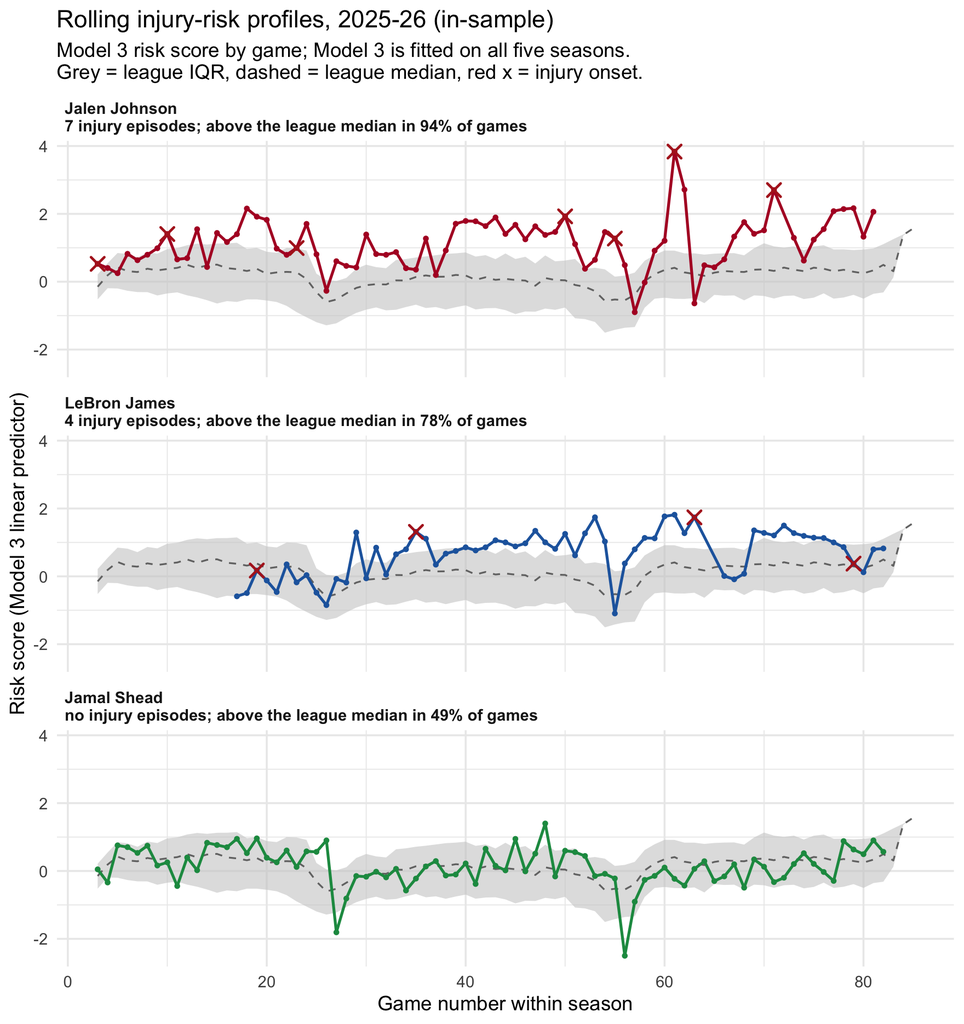

```r
fig_profiles <- ggplot() +
  geom_ribbon(data = band_f, aes(game, ymin = q1, ymax = q3), fill = "grey80", alpha = .6) +
  geom_line(data = band_f, aes(game, med), colour = "grey45", linetype = "dashed", linewidth = .5) +
  geom_line(data = ex, aes(t_stop, risk_lp, group = seg, colour = facet), linewidth = .8) +
  geom_point(data = ex, aes(t_stop, risk_lp, colour = facet), size = .9) +
  geom_point(data = events, aes(t_stop, risk_lp), shape = 4, size = 3, stroke = 1.1,
             colour = "firebrick") +
  facet_wrap(~ facet, ncol = 1) +
  scale_colour_manual(values = c("#b2182b", "#2166ac", "#1a9850"), guide = "none") +
  labs(title = paste0("Rolling injury-risk profiles, ", TEST, " (in-sample)"),
       subtitle = paste0("Model 3 risk score by game; Model 3 is fitted on all five seasons.\n",
                         "Grey = league IQR, dashed = league median, red x = injury onset."),
       x = "Game number within season", y = "Risk score (Model 3 linear predictor)") +
  theme_minimal(base_size = 12) +
  theme(strip.text = element_text(face = "bold", hjust = 0))
fig_profiles
```

## 9.1 What it shows

The quintile table is the general claim: player-level mean risk score orders injury count across the season (Spearman rho = 0.59), so the three profiles illustrate a real relationship rather than standing in for one.

Jalen Johnson sits above the league median in 94% of his games with 7 onsets, the season’s highest burden. LeBron James is above the median in 78% of games with 4 onsets. Jamal Shead played 80 games with 0 onsets and sits around the league median (above it in 49% of games). At concordance 0.74, about 26% of comparable pairs are ordered wrongly, so a three-player figure has no right to be immune.

A note on what these profiles are scored against. The instinct is to validate against games missed, and that is the wrong target. Across the 450 players with 40+ modelled intervals in 2025-26, mean risk score correlates with games missed at Spearman -0.62, negative: higher-scoring players miss fewer games, because a high score requires high load and high load requires being available. Games missed mixes injury with rest, load management and coaching decisions. Onsets are what the model is fitted to.

Two caveats. The score is relative, so it ranks but gives no absolute probability. And Shead, injury-free across a full season, still sits on the league median rather than below it, which is the health-selection wall made visual: you cannot post a very low load-based score and play a full season, because availability is what drives the load (and the recent-games count) the score is built from. The lowest scores in the league belong to players barely in the rotation, so a full-season player makes a poor low-risk exemplar.

The why lives in the same object. The score is a weighted sum, so a player’s elevation on any game decomposes into how much comes from acute load, congestion or injury history, which is the per-player readout a practitioner would act on.

# 10 Conclusion

Where I got to, and what carries into the article.

1. The workload association is dominated by exposure measures. Chronic load (2.109) and recent games played (2.046) are the two largest workload terms in Model 3, and both are raised for every injury mechanism, the impact control included (chronic load 1.779 on reported-pathology overuse against 2.04 on impact injuries). That is the pattern exposure and selection would produce, not a fatigue gradient. Acute load adds nothing on average once those are held fixed (0.963 in Model 3).
2. An exploratory fatigue-consistent pattern, in one subset. Acute load is 1.64 (95% CI 1.17-2.30) for overuse where a pathology is reported, not distinguishable from 1 elsewhere, and the difference from the control holds in a direct contrast, ratio 1.58 (95% CI 1.05-2.40, p = 0.030). The pre-specified pooled comparison does not, ratio 0.94 (95% CI 0.67-1.31, p = 0.720), and the split came after seeing it, so this is consistent with a fatigue pathway, not an identification of one.
3. Measurement may be hiding what signal there is. Where the report says only that something is sore, acute load is 0.816 on 1,338 events. If most of what availability text records as overuse is precautionary rest written down as a symptom, surveillance built on that text will understate any workload association with overuse injury.
4. Prior injury is the largest change in a player’s risk profile, and the covariates do not carry it. Holding workload, schedule and context equal, a player in their second injury spell of a season carries 1.84x the baseline hazard of a player in their first and a third-or-later spell 2.83x. Because the spell strata take no coefficient, none of that is attributable to load; it sits in the baseline, where no amount of load management would show it.
5. Load is interchangeable with minutes, and catching why mattered. I report load as the better construct, and the model holds identically on minutes. An earlier version had load out-predicting minutes for soft tissue (0.693 → 0.744); that was a tracking-data bug, DNP games leaking a fake zero distance through the carry-forward, not a real edge. Distance is the right idea, but in public data total load ≈ minutes (r ≈ 0.99) and the injurious high-speed component is unobserved.
6. Background risk rises across the season. Model 3’s per-game baseline hazard is 1.54x higher in games 55-75 than 5-25, with the post-All-Star term (2.132) carrying part of the late-season rise as well. The workload terms show no detected change in relative effect across the season, so it is the baseline that moves, not how those terms act. It is a residual conditional on the model, and on its own it does not say which scheduling change would help.
7. Proneness is real, and the covariates absorb about 70% of it. θ = 0.293 against 0.963 unadjusted, so the 90th-to-10th spread narrows from 12.4x to 4x. What remains is the reach of public data.

## 10.1 Limitations

# 11 Appendix - Robustness and sensitivity checks

Checks that the headline result does not depend on a modelling choice I made. Each re-fits the reported specification with one decision changed and reports what moves. They sit here rather than in the main sequence because none of them changes a conclusion; the point of each is that nothing happens.

## 11.1 Does the exposure choice matter?

Load and minutes are ~0.995 collinear, so does the choice matter? Refitting Model 3 with minutes swapped in leaves discrimination and the headline hazard ratios essentially unchanged.

```r
m3_min <- fit_cox(m3_terms_min)   # same Model 3, minutes in place of load

robust_tab <- tibble(
  Metric = c("Concordance", "Chronic workload HR (per SD)",
             "Acute workload HR (per SD)"),
  `Load (reported)` = c(
    round(summary(m3)$concordance[1], 4),
    hr(m3, "z_ROLLING_LOAD_28D"), hr(m3, "z_ROLLING_LOAD_7D")),
  `Minutes (robustness)` = c(
    round(summary(m3_min)$concordance[1], 4),
    hr(m3_min, "z_ROLLING_MIN_28D"), hr(m3_min, "z_ROLLING_MIN_7D"))
)
show_tbl(robust_tab, "Robustness - on-court load vs minutes give the same answer")
```

Robustness - on-court load vs minutes give the same answer

| Metric | Load (reported) | Minutes (robustness) |
| --- | --- | --- |
| Concordance | 0.738 | 0.737 |
| Chronic workload HR (per SD) | 2.109 | 2.135 |
| Acute workload HR (per SD) | 0.963 | 1.021 |

So the exposure choice is not driving the result. I lead with load because it is the better construct, what the body absorbed rather than what the coach decided.

## 11.2 Is the 2-games-back term its own signal?

Lag-2 carries correctly-signed load effect in the model. Two ways it could be an illusion: it might just be re-expressing the 7d/28d rolling windows, or its contribution might be in-sample overfitting.

```r
load_block <- c("z_ROLLING_LOAD_7D", "z_ROLLING_LOAD_28D")

# How much of lag-2 do the rolling windows explain? VIF < 5 = estimable alongside them.
lag2_vif <- 1 / (1 - summary(lm(z_PREV_2GAME_DISTANCE ~ z_ROLLING_LOAD_7D +
                   z_ROLLING_LOAD_28D, data = cox))$r.squared)

# Out of sample: refit on 2021-25, score the unseen 2025-26, with and without lag-2.
tr <- cox %>% filter(SEASON != "2025-26"); te <- cox %>% filter(SEASON == "2025-26")
oos_c <- function(terms) {           # no season strata, so the score transfers
  f <- coxph(as.formula(paste0(surv_lhs, " ~ ", paste(terms, collapse = " + "),
                               " + cluster(PLAYER_ID)")), data = tr, ties = "efron")
  d <- te; d$.lp <- as.numeric(predict(f, newdata = te, type = "lp"))
  round(concordance(Surv(t_start, t_stop, event) ~ .lp, data = d, reverse = TRUE)$concordance, 4)
}

oos_with <- oos_c(m3_terms)
oos_less <- oos_c(setdiff(m3_terms, "z_PREV_2GAME_DISTANCE"))

lag2_tab <- tibble(
  Check = c("VIF of lag-2 against the rolling-load block",
            "Out-of-sample C, lag-2 in the model",
            "Out-of-sample C, lag-2 dropped"),
  Value = c(round(lag2_vif, 2),
            oos_with, oos_less))
show_tbl(lag2_tab, "Is the 2-games-back term its own signal?")
```

Is the 2-games-back term its own signal?

| Check | Value |
| --- | --- |
| VIF of lag-2 against the rolling-load block | 2.650 |
| Out-of-sample C, lag-2 in the model | 0.744 |
| Out-of-sample C, lag-2 dropped | 0.741 |

What justifies keeping it is the hold-out: concordance 0.7436 with lag-2 against 0.7408 without. It adds predictive value on a season the model never saw, which is the test that matters for a term I report as a finding.

## 11.3 Does intensity add anything beyond volume?

Load and minutes are both volume. Intensity is the obvious candidate for what they miss: how hard, not how long. It is nearly uncorrelated with the load terms, so if it carried independent signal this is where it would show. I add the same prospective lag pair to Model 3 and test whether both terms are jointly zero.

```r
# Fit on the rows where intensity is defined for BOTH models, so the comparison is like for like (intensity needs >=10 minutes played, so it is missing more often than load).
need_int <- c(setdiff(m3_terms, "I(z_SEASONS_IN_LEAGUE^2)"), intensity_terms)
cox_int  <- cox %>% filter(if_all(all_of(need_int), ~ !is.na(.)))

m3_int_base <- coxph(as.formula(paste0(surv_lhs, " ~ ", paste(m3_terms, collapse = " + "),
                     " + ", rhs_tail)), data = cox_int, ties = "efron")
m3_int_plus <- coxph(as.formula(paste0(surv_lhs, " ~ ",
                     paste(c(m3_terms, intensity_terms), collapse = " + "),
                     " + ", rhs_tail)), data = cox_int, ties = "efron")

# Joint robust Wald test that both intensity coefficients are zero.
cf <- coef(m3_int_plus); V <- vcov(m3_int_plus); idx <- match(intensity_terms, names(cf))
int_wald <- as.numeric(t(cf[idx]) %*% solve(V[idx, idx]) %*% cf[idx])
int_p    <- pchisq(int_wald, length(idx), lower.tail = FALSE)

intensity_tab <- tibble(
  Metric = c("Concordance", "Chronic load HR (per SD)", "Acute load HR (per SD)",
             "In-game intensity, last game (per SD)", "In-game intensity, 2 games back (per SD)"),
  `Model 3` = c(round(summary(m3_int_base)$concordance[1], 4),
                hr(m3_int_base, "z_ROLLING_LOAD_28D"), hr(m3_int_base, "z_ROLLING_LOAD_7D"), NA, NA),
  `+ intensity` = c(round(summary(m3_int_plus)$concordance[1], 4),
                hr(m3_int_plus, "z_ROLLING_LOAD_28D"), hr(m3_int_plus, "z_ROLLING_LOAD_7D"),
                hr(m3_int_plus, "z_PREV_GAME_INTENSITY"), hr(m3_int_plus, "z_PREV_2GAME_INTENSITY"))
)
show_tbl(intensity_tab, paste0("Intensity robustness - joint Wald test that both intensity terms are zero: p = ",
                               fmt_p(int_p)))
```

Intensity robustness - joint Wald test that both intensity terms are zero: p = 0.029

Metric

Model 3

- intensity

Concordance

0.724

0.724

Chronic load HR (per SD)

2.148

2.126

Acute load HR (per SD)

1.031

1.024

In-game intensity, last game (per SD)

NA

1.004

In-game intensity, 2 games back (per SD)

NA

0.928

## 11.4 Does the tier pattern depend on how acute load is expressed?

Acute load and recent games played are both in Model 3, and they are strongly correlated. Holding games fixed is what lets the acute coefficient mean load concentrated within the same number of recent games. The obvious alternative expresses that concentration directly, as distance per recent game, in place of total seven-day distance. If the Stage 6 pattern (acute load raised only for overuse with a reported pathology) is robust, it should survive that change.

```r
# Distance per appearance over the last 7 days (0 when no games), standardised like
# every other continuous term.
cox$LOAD_PER_GAME_7D   <- ifelse(cox$ROLLING_GAMES_7D > 0,
                                 cox$ROLLING_LOAD_7D / cox$ROLLING_GAMES_7D, 0)
cox$z_LOAD_PER_GAME_7D <- as.numeric(scale(cox$LOAD_PER_GAME_7D))

rho_games_acute <- cor(cox$ROLLING_GAMES_7D, cox$ROLLING_LOAD_7D,
                       method = "spearman", use = "complete.obs")
# Refit Model 3 here rather than reuse the cached m3: a cached fit cannot rebuild its
# model matrix (see the note in Stage 4).
m3_now <- fit_outcome("event", m3_terms)
vif_m3 <- diag(solve(cor(model.matrix(m3_now))))

pg_terms <- c(setdiff(m3_terms, "z_ROLLING_LOAD_7D"), "z_LOAD_PER_GAME_7D")
pg_fits  <- list(fit_outcome("ev_rep_named", pg_terms), fit_outcome("ev_rep_vague", pg_terms),
                 fit_outcome("event_acute_nc", pg_terms), fit_outcome("event_acute_imp", pg_terms))
m3_pg    <- fit_outcome("event", pg_terms)

ct_rep_pg  <- tier_contrast("ev_rep_named",     "event_acute_imp", "reported", "impact",
                            terms = pg_terms, focus = "z_LOAD_PER_GAME_7D")
ct_pool_pg <- tier_contrast("event_repetitive", "event_acute_imp", "overuse",  "impact",
                            terms = pg_terms, focus = "z_LOAD_PER_GAME_7D")

acute_form_tab <- tibble(
  ` ` = c(nms, "Reported / control", "All overuse / control", "Model 3 concordance"),
  `Total 7-day distance (primary)` = c(
    map_chr(mods, ~ ci_cell(.x, "z_ROLLING_LOAD_7D")),
    ratio_cell(ct_rep, "z_ROLLING_LOAD_7D"), ratio_cell(ct_pool, "z_ROLLING_LOAD_7D"),
    sprintf("%.3f", summary(m3)$concordance[1])),
  `Distance per recent game` = c(
    map_chr(pg_fits, ~ ci_cell(.x, "z_LOAD_PER_GAME_7D")),
    ratio_cell(ct_rep_pg, "z_LOAD_PER_GAME_7D"), ratio_cell(ct_pool_pg, "z_LOAD_PER_GAME_7D"),
    sprintf("%.3f", summary(m3_pg)$concordance[1])))
show_tbl(acute_form_tab, paste0(
  "Acute-load term by tier under two forms (HR per SD, 95% CI; contrasts from the joint model). ",
  "Spearman correlation of games played and acute load (7d): ", sprintf("%.2f", rho_games_acute),
  "; VIF of acute load in Model 3: ", sprintf("%.1f", vif_m3[["z_ROLLING_LOAD_7D"]])))
```

Acute-load term by tier under two forms (HR per SD, 95% CI; contrasts from the joint model). Spearman correlation of games played and acute load (7d): 0.86; VIF of acute load in Model 3: 12.2

|  | Total 7-day distance (primary) | Distance per recent game |
| --- | --- | --- |
| Overuse (pathology reported) | 1.64 (1.17-2.30) | 1.95 (1.17-3.23) |
| Overuse (symptom only) | 0.82 (0.66-1.01) | 1.87 (1.41-2.49) |
| Acute non-contact | 0.89 (0.72-1.11) | 2.23 (1.61-3.10) |
| Acute impact (control) | 1.03 (0.79-1.36) | 1.92 (1.23-2.99) |
| Reported / control | 1.58 (1.05-2.40), p = 0.030 | 1.02 (0.52-1.97), p = 0.964 |
| All overuse / control | 0.94 (0.67-1.31), p = 0.720 | 0.98 (0.58-1.64), p = 0.933 |
| Model 3 concordance | 0.738 | 0.741 |

The Stage 6 pattern does not survive the change of form. Expressed as distance per recent game, the load term is 1.92 (1.23-2.99) on the impact control and 1.95 (1.17-3.23) on overuse with a reported pathology, and the contrast between them is 1.02 (95% CI 0.52-1.97, p = 0.964). Discrimination is essentially the same under either form. So the acute-load difference between tiers depends on how acute load is expressed, which is one more reason the tier result is reported as exploratory. The exposure terms stay large under both forms: with the per-game form, chronic load is 1.844 and recent games played 1.824 in Model 3, against 2.109 and 2.046 in the primary form, and load per recent game itself is 1.98 (95% CI 1.63-2.40) for all new injuries.

## 11.5 Does holding the 28-day game count fixed change chronic load?

Recent games played is what lets the acute term mean load concentrated within the same number of games. The same move on the chronic side holds the number of games in the last 28 days fixed, leaving 28-day distance at the same game count. If that remainder were fatigue, it should be larger for overuse than for the impact control. Two forms are tested: Model 3 with games played in the last 28 days added, and chronic load expressed as distance per game over 28 days alongside that count.

```r
cox$z_ROLLING_GAMES_28D <- as.numeric(scale(cox$ROLLING_GAMES_28D))
cox$LOAD_PER_GAME_28D   <- ifelse(cox$ROLLING_GAMES_28D > 0,
                                  cox$ROLLING_LOAD_28D / cox$ROLLING_GAMES_28D, 0)
cox$z_LOAD_PER_GAME_28D <- as.numeric(scale(cox$LOAD_PER_GAME_28D))

chronic_forms <- list(
  primary = list(label = "Model 3 (primary)", term = "z_ROLLING_LOAD_28D",
                 terms = m3_terms),
  games28 = list(label = "+ games played (28d)", term = "z_ROLLING_LOAD_28D",
                 terms = c(m3_terms, "z_ROLLING_GAMES_28D")),
  pergame = list(label = "Distance per game (28d) + games played (28d)", term = "z_LOAD_PER_GAME_28D",
                 terms = c(setdiff(m3_terms, "z_ROLLING_LOAD_28D"),
                           "z_LOAD_PER_GAME_28D", "z_ROLLING_GAMES_28D")))

# Every fit uses Model 3's rows, so concordance and AIC are comparable across forms.
chronic_fits <- map(chronic_forms, function(s) list(
  all   = fit_outcome("event", s$terms),
  tiers = map(c("ev_rep_named", "ev_rep_vague", "event_acute_nc", "event_acute_imp"),
              ~ fit_outcome(.x, s$terms)),
  rep   = tier_contrast("ev_rep_named",     "event_acute_imp", "reported", "impact",
                        terms = s$terms, focus = s$term),
  pool  = tier_contrast("event_repetitive", "event_acute_imp", "overuse",  "impact",
                        terms = s$terms, focus = s$term)))

chronic_form_tab <- imap_dfr(chronic_forms, function(s, k) {
  f <- chronic_fits[[k]]
  tibble(Specification = s$label,
         `All new injuries` = ci_cell(f$all, s$term),
         !!!set_names(as.list(map_chr(f$tiers, ~ ci_cell(.x, s$term))), nms),
         `Reported / control`    = ratio_cell(f$rep,  s$term),
         `All overuse / control` = ratio_cell(f$pool, s$term),
         C   = sprintf("%.3f", summary(f$all)$concordance[1]),
         AIC = sprintf("%.1f", AIC(f$all)))
})
show_tbl(chronic_form_tab, paste0(
  "Chronic-load term by tier under three forms (HR per SD, 95% CI; contrasts from the joint model). ",
  "Spearman correlation of games played (28d) and chronic load: ",
  sprintf("%.2f", cor(cox$ROLLING_GAMES_28D, cox$ROLLING_LOAD_28D, method = "spearman"))))
```

Chronic-load term by tier under three forms (HR per SD, 95% CI; contrasts from the joint model). Spearman correlation of games played (28d) and chronic load: 0.89

Specification

All new injuries

Overuse (pathology reported)

Overuse (symptom only)

Acute non-contact

Acute impact (control)

Reported / control

All overuse / control

C

AIC

Model 3 (primary)

2.11 (1.91-2.32)

1.78 (1.36-2.32)

1.98 (1.70-2.31)

2.28 (1.95-2.66)

2.04 (1.63-2.55)

0.87 (0.62-1.23), p = 0.432

0.94 (0.73-1.22), p = 0.660

0.738

43852.3

- games played (28d)

2.47 (2.15-2.83)

1.98 (1.39-2.82)

2.16 (1.73-2.70)

2.95 (2.38-3.66)

2.17 (1.59-2.95)

0.91 (0.57-1.46), p = 0.704

0.98 (0.68-1.41), p = 0.903

0.738

43841.1

Distance per game (28d) + games played (28d)

3.00 (2.68-3.36)

2.32 (1.68-3.21)

2.42 (2.02-2.89)

3.74 (3.12-4.49)

2.93 (2.24-3.83)

0.79 (0.52-1.21), p = 0.283

0.82 (0.60-1.12), p = 0.210

0.744

43615.1

```r
pg28_zph  <- cox.zph(chronic_fits$pergame$all, transform = "identity")$table["z_LOAD_PER_GAME_28D", "p"]
aic_gain  <- AIC(chronic_fits$primary$all) - AIC(chronic_fits$pergame$all)
```

Neither form makes chronic load specific to overuse. With the 28-day game count held fixed, chronic load is 2.17 (1.59-2.95) on the impact control against 1.98 (1.39-2.82) on overuse with a reported pathology, a ratio of 0.91 (95% CI 0.57-1.46, p = 0.704). In the per-game form the ratio is 0.79 (95% CI 0.52-1.21, p = 0.283). Distance at a fixed number of games is mostly minutes per game (load and minutes correlate at ~0.995), so what remains is still time on court, per game rather than in total, which is exposure. Model 3 stays as it is.

The per-game form does fit better: concordance 0.744 against 0.738, AIC lower by 237, with distance per game the largest term in the model and elevated in every tier. I found that after looking, and its proportional-hazards test flags (p = 0.022), so it is a lead for an exposure measure to prespecify in future work rather than a result here.